# Examen de projet statistique sur R, ISE1 2024-2025

DJERAKEI MISTALENGAR

13 mai 2025

# 1 Gestion des packages

```r
# Fixation du miroir CRAN
options(repos = c(CRAN = "https://cloud.r-project.org"))

# Installation et chargement via pacman
if (!require("pacman")) install.packages("pacman")

packages <- c("haven", "knitr", "gtsummary","gt","utils", "tidyverse", "labelled", "expss", "sjPlot", "janitor", "sf", "leaflet", "htmltools", "ggspatial")
pacman::p_load(char = packages)
```

```r
# Supprimer toutes les variables de l'environnement
rm(list = ls())

# Forcer un nettoyage de la mémoire
gc()
```

```
##           used (Mb) gc trigger  (Mb) max used  (Mb)
## Ncells 1388532 74.2    2418135 129.2  2418135 129.2
## Vcells 2368457 18.1    8388608  64.0  3641898  27.8
```

# 2 Chargement des Données

```r
# Charger les bases sans conversion immédiate des labels

Ind <- read_dta("../Donnees/Base_Individus.dta")


Prin <- read_dta("../Donnees/Base_Principale.dta")
```

# 3 I. Analyse de consistance des bases de données

Cette section vise à vérifier la qualité des données importées et à appliquer les transformations nécessaires pour assurer leur cohérence avant l’analyse. Nous utiliserons principalement les packages `janitor` et `tidyverse` pour cette tâche.

## 3.1 Analyse préliminaire des bases de données

Commençons par examiner les dimensions et les caractéristiques générales de nos bases de données.

```r
# Dimensions des bases de données
cat("Dimensions de la base Ind:", dim(Ind), "\n")
```

```
## Dimensions de la base Ind: 22092 144
```

```r
cat("Dimensions de la base Prin:", dim(Prin), "\n")
```

```
## Dimensions de la base Prin: 3058 1312
```

```r
# Vérification des valeurs manquantes par colonne
cat("\nNombre de valeurs manquantes par colonne (top 10) - Base Ind:\n")
```

```
##
## Nombre de valeurs manquantes par colonne (top 10) - Base Ind:
```

```r
na_count_ind <- sapply(Ind, function(y) sum(length(which(is.na(y)))))
head(sort(na_count_ind, decreasing = TRUE), 10)
```

```
## HH_00b_month  HH_00b_year       HH_11b       Dis_18       Dis_15       Dis_12
##        22089        22077        22025        21978        21954        21879
##        ID_04        HH_16        ID_06       Dis_06
##        21852        21760        21710        21692
```

```r
cat("\nNombre de valeurs manquantes par colonne (top 10) - Base Prin:\n")
```

```
##
## Nombre de valeurs manquantes par colonne (top 10) - Base Prin:
```

```r
na_count_prin <- sapply(Prin, function(y) sum(length(which(is.na(y)))))
head(sort(na_count_prin, decreasing = TRUE), 10)
```

```
## HH_31b16 HH_31b17 HH_31b18 HH_31b19 HH_31b20 HH_31b21 HH_31b22 HH_31b23
##     3058     3058     3058     3058     3058     3058     3058     3058
## HH_31b24 HH_31b25
##     3058     3058
```

```r
# Pourcentage global de valeurs manquantes
cat("\nPourcentage global de valeurs manquantes - Base Ind:",
    round(sum(is.na(Ind)) / (nrow(Ind) * ncol(Ind)) * 100, 2), "%\n")
```

```
##
## Pourcentage global de valeurs manquantes - Base Ind: 64.64 %
```

```r
cat("Pourcentage global de valeurs manquantes - Base Prin:",
    round(sum(is.na(Prin)) / (nrow(Prin) * ncol(Prin)) * 100, 2), "%\n")
```

```
## Pourcentage global de valeurs manquantes - Base Prin: 65.55 %
```

## 3.2 Nettoyage des bases de données avec janitor

Le package `janitor` offre des fonctions utiles pour nettoyer les bases de données. Appliquons quelques-unes de ces fonctions à nos bases.

```r
# Vérification des colonnes vides ou presque vides dans chaque base
empty_cols_ind <- colnames(Ind)[colSums(is.na(Ind)) > 0.9 * nrow(Ind)]
cat("Colonnes presque vides (>90% NA) dans la base Ind:", length(empty_cols_ind), "\n")
```

```
## Colonnes presque vides (>90% NA) dans la base Ind: 36
```

```r
if(length(empty_cols_ind) > 0) head(empty_cols_ind, 10)
```

```
##  [1] "HH_00a_year"  "HH_00a_month" "HH_00b_year"  "HH_00b_month" "HH_11b"
##  [6] "ID_04"        "ID_06"        "HH_07b"       "HH_10name16"  "HH_10name17"
```

```r
empty_cols_prin <- colnames(Prin)[colSums(is.na(Prin)) > 0.9 * nrow(Prin)]
cat("\nColonnes presque vides (>90% NA) dans la base Prin:", length(empty_cols_prin), "\n")
```

```
##
## Colonnes presque vides (>90% NA) dans la base Prin: 589
```

```r
if(length(empty_cols_prin) > 0) head(empty_cols_prin, 10)
```

```
##  [1] "HH_31b1"  "HH_31b2"  "HH_31b3"  "HH_31b4"  "HH_31b5"  "HH_31b6"
##  [7] "HH_31b7"  "HH_31b8"  "HH_31b9"  "HH_31b10"
```

```r
# Vérification des lignes vides ou presque vides
empty_rows_ind <- which(rowSums(is.na(Ind)) > 0.9 * ncol(Ind))
cat("\nLignes presque vides (>90% NA) dans la base Ind:", length(empty_rows_ind), "\n")
```

```
##
## Lignes presque vides (>90% NA) dans la base Ind: 0
```

```r
empty_rows_prin <- which(rowSums(is.na(Prin)) > 0.9 * ncol(Prin))
cat("Lignes presque vides (>90% NA) dans la base Prin:", length(empty_rows_prin), "\n")
```

```
## Lignes presque vides (>90% NA) dans la base Prin: 0
```

```r
# Standardisation des noms de colonnes
# Nous créons des copies pour ne pas modifier les bases originales
Ind_clean <- Ind
Prin_clean <- Prin

# Vérification des noms de colonnes avant et après nettoyage (quelques exemples)
cat("\nExemple de noms de colonnes avant/après nettoyage - Base Ind:\n")
```

```
##
## Exemple de noms de colonnes avant/après nettoyage - Base Ind:
```

```r
head(data.frame(original = names(Ind), nettoyé = names(Ind_clean)), 5)
```

| original | nettoyé |
| --- | --- |
| Intro_07_1 | Intro_07_1 |
| start | start |
| end | end |
| admin0 | admin0 |
| admin1 | admin1 |

```r
cat("\nExemple de noms de colonnes avant/après nettoyage - Base Prin:\n")
```

```
##
## Exemple de noms de colonnes avant/après nettoyage - Base Prin:
```

```r
head(data.frame(original = names(Prin), nettoyé = names(Prin_clean)), 5)
```

| original | nettoyé |
| --- | --- |
| Intro_07_1 | Intro_07_1 |
| start | start |
| end | end |
| admin0 | admin0 |
| admin1 | admin1 |

## 3.3 Suppression des colonnes et lignes inutiles

Sur la base de l’analyse ci-dessus, nous pouvons décider de supprimer certaines colonnes ou lignes qui contiennent principalement des valeurs manquantes. Cependant, il est important de ne pas supprimer des données qui pourraient être pertinentes pour l’analyse.

```r
# Suppression des colonnes presque vides (seuil de 95%)
Ind_clean <- Ind_clean %>%
  select(where(~sum(is.na(.)) < 0.95 * nrow(Ind_clean)))

Prin_clean <- Prin_clean %>%
  select(where(~sum(is.na(.)) < 0.95 * nrow(Prin_clean)))

# Comparaison des dimensions avant et après la suppression des colonnes
cat("Dimensions de la base Ind avant:", dim(Ind), "\n")
```

```
## Dimensions de la base Ind avant: 22092 144
```

```r
cat("Dimensions de la base Ind après:", dim(Ind_clean), "\n\n")
```

```
## Dimensions de la base Ind après: 22092 116
```

```r
cat("Dimensions de la base Prin avant:", dim(Prin), "\n")
```

```
## Dimensions de la base Prin avant: 3058 1312
```

```r
cat("Dimensions de la base Prin après:", dim(Prin_clean), "\n")
```

```
## Dimensions de la base Prin après: 3058 873
```

```r
# Suppression des lignes presque vides (seuil de 95%)
Ind_clean <- Ind_clean %>%
  filter(rowSums(is.na(.)) < 0.95 * ncol(.))

Prin_clean <- Prin_clean %>%
  filter(rowSums(is.na(.)) < 0.95 * ncol(.))

# Comparaison après la suppression des lignes
cat("\nDimensions de la base Ind après suppression des lignes:", dim(Ind_clean), "\n")
```

```
##
## Dimensions de la base Ind après suppression des lignes: 22092 116
```

```r
cat("Dimensions de la base Prin après suppression des lignes:", dim(Prin_clean), "\n")
```

```
## Dimensions de la base Prin après suppression des lignes: 3058 873
```

## 3.4 Traitement des doublons

Vérifions s’il existe des doublons dans les bases de données.

```r
# Vérification des doublons basés sur l'identifiant unique (ID)
duplicated_id_ind <- Ind_clean %>%
  group_by(ID) %>%
  filter(n() > 1) %>%
  summarise(n = n())

cat("Nombre de lignes avec des IDs dupliqués dans la base Ind:", nrow(duplicated_id_ind), "\n")
```

```
## Nombre de lignes avec des IDs dupliqués dans la base Ind: 2971
```

```r
# Pour la base Prin, chaque ligne devrait être unique
duplicated_rows_prin <- Prin_clean %>%
  janitor::get_dupes()

cat("Nombre de lignes dupliquées dans la base Prin:", nrow(duplicated_rows_prin), "\n")
```

```
## Nombre de lignes dupliquées dans la base Prin: 0
```

## 3.5 Cohérence entre les bases de données

Vérifions la cohérence entre les bases de données Ind et Prin, notamment la correspondance des identifiants.

```r
# Vérifier que chaque ID dans Ind existe dans Prin
ids_in_ind_not_in_prin <- setdiff(unique(Ind_clean$ID), unique(Prin_clean$ID))
cat("Nombre d'IDs dans Ind qui n'existent pas dans Prin:", length(ids_in_ind_not_in_prin), "\n")
```

```
## Nombre d'IDs dans Ind qui n'existent pas dans Prin: 0
```

```r
# Vérifier que chaque ID dans Prin existe dans Ind
ids_in_prin_not_in_ind <- setdiff(unique(Prin_clean$ID), unique(Ind_clean$ID))
cat("Nombre d'IDs dans Prin qui n'existent pas dans Ind:", length(ids_in_prin_not_in_ind), "\n")
```

```
## Nombre d'IDs dans Prin qui n'existent pas dans Ind: 0
```

## 3.6 Traitement des valeurs aberrantes

Examinons certaines variables numériques clés pour détecter d’éventuelles valeurs aberrantes.

```r
# Exemple avec la variable âge
if("ageYears" %in% names(Ind_clean)) {
  summary(Ind_clean$ageYears)

  # Identifier les valeurs aberrantes (par exemple, âge > 120 ans)
  outliers_age <- Ind_clean %>%
    filter(ageYears > 120 | ageYears < 0)

  cat("Nombre de valeurs aberrantes pour l'âge:", nrow(outliers_age), "\n")

  # Si nécessaire, corriger les valeurs aberrantes
  Ind_clean <- Ind_clean %>%
    mutate(ageYears = ifelse(ageYears > 120 | ageYears < 0, NA, ageYears))
}
```

```
## Nombre de valeurs aberrantes pour l'âge: 0
```

## 3.7 Standardisation des types de données

S’assurer que les variables ont le type approprié.

```r
# Exemple de conversion de type pour certaines variables
Ind_clean <- Ind_clean %>%
  mutate(across(starts_with("HH") & where(is.double) & !where(is.labelled), as.integer))

# Vérifier les types de données après conversion (quelques exemples)
lapply(Ind_clean %>% select(starts_with("HH") & where(is.integer)) %>% head(5), class)
```

```
## $HH_03
## [1] "integer"
##
## $HH_02
## [1] "integer"
##
## $HH_00
## [1] "integer"
##
## $HH_00a_year
## [1] "integer"
##
## $HH_00a_month
## [1] "integer"
##
## $HH_11a
## [1] "integer"
##
## $HH_13
## [1] "integer"
##
## $HH_06
## [1] "integer"
##
## $HH_07a
## [1] "integer"
##
## $HH_08
## [1] "integer"
##
## $HH_10hhmemberother
## [1] "integer"
##
## $HH_10name1
## [1] "integer"
##
## $HH_10name2
## [1] "integer"
##
## $HH_10name3
```

[output cut: 193 more lines]

```
##
## $HH_Educ15b
## [1] "integer"
##
## $HH_Educ16
## [1] "integer"
##
## $HH_Educ17
## [1] "integer"
##
## $HH_Educ18
## [1] "integer"
##
## $HH_Educ23
## [1] "integer"
```

## 3.8 Résumé du nettoyage

```r
# Résumé des modifications apportées
cat("Résumé des modifications apportées:\n")
```

```
## Résumé des modifications apportées:
```

```r
cat("1. Colonnes supprimées (>95% NA) - Base Ind:", ncol(Ind) - ncol(Ind_clean), "\n")
```

```
## 1. Colonnes supprimées (>95% NA) - Base Ind: 28
```

```r
cat("2. Colonnes supprimées (>95% NA) - Base Prin:", ncol(Prin) - ncol(Prin_clean), "\n")
```

```
## 2. Colonnes supprimées (>95% NA) - Base Prin: 439
```

```r
cat("3. Lignes supprimées (>95% NA) - Base Ind:", nrow(Ind) - nrow(Ind_clean), "\n")
```

```
## 3. Lignes supprimées (>95% NA) - Base Ind: 0
```

```r
cat("4. Lignes supprimées (>95% NA) - Base Prin:", nrow(Prin) - nrow(Prin_clean), "\n")
```

```
## 4. Lignes supprimées (>95% NA) - Base Prin: 0
```

```r
# Pourcentage final de valeurs manquantes
cat("\nPourcentage final de valeurs manquantes - Base Ind:",
    round(sum(is.na(Ind_clean)) / (nrow(Ind_clean) * ncol(Ind_clean)) * 100, 2), "%\n")
```

```
##
## Pourcentage final de valeurs manquantes - Base Ind: 56.8 %
```

```r
cat("Pourcentage final de valeurs manquantes - Base Prin:",
    round(sum(is.na(Prin_clean)) / (nrow(Prin_clean) * ncol(Prin_clean)) * 100, 2), "%\n")
```

```
## Pourcentage final de valeurs manquantes - Base Prin: 48.97 %
```

## 3.9 Finalisation des bases de données nettoyées

Remplaçons les bases de données originales par les versions nettoyées pour la suite de l’analyse.

```r
# Remplacement des bases originales
Ind <- Ind_clean
Prin <- Prin_clean

# Libération de la mémoire
rm(Ind_clean, Prin_clean)
gc()
```

```
##           used (Mb) gc trigger  (Mb) max used  (Mb)
## Ncells 1478968 79.0    2418135 129.2  2418135 129.2
## Vcells 6884300 52.6   25321352 193.2 21608229 164.9
```

# 4 Exploration des données

## 4.1 Structure des bases de données

Pour mieux comprendre les données, examinons la structure des deux bases et les principales variables disponibles.

```r
# Nombre d'observations et de variables
dim(Ind)
```

```
## [1] 22092   116
```

```r
dim(Prin)
```

```
## [1] 3058  873
```

```r
# Résumé des variables de la base Individus
str(Ind)
```

```
## tibble [22,092 × 116] (S3: tbl_df/tbl/data.frame)
##  $ Intro_07_1            : dbl+lbl [1:22092] 1, 1, 1, 1, 1, 1, 1, 1, 1, 1, 1, 1, 1, 1, 1, 1, 1, 1...
##    ..@ label       : chr "Population group"
##    ..@ format.stata: chr "%10.0g"
##    ..@ labels      : Named num [1:4] 1 2 3 4
##    .. ..- attr(*, "names")= chr [1:4] "Refugees" "Asylum-seekers" "Host community North" "Returnees"
##  $ start                 : Date[1:22092], format: "2023-04-29" "2023-04-29" ...
##  $ end                   : Date[1:22092], format: "2023-04-29" "2023-04-29" ...
##  $ admin0                : chr [1:22092] "SSD" "SSD" "SSD" "SSD" ...
##   ..- attr(*, "label")= chr "Host country"
##   ..- attr(*, "format.stata")= chr "%-9s"
##  $ admin1                : dbl+lbl [1:22092] 3, 3, 3, 3, 3, 3, 3, 3, 3, 3, 3, 3, 3, 3, 3, 2, 2, 2...
##    ..@ label       : chr "State"
##    ..@ format.stata: chr "%10.0g"
##    ..@ labels      : Named num [1:6] 1 2 3 4 5 6
##    .. ..- attr(*, "names")= chr [1:6] "Unity" "Upper Nile" "Central Equatoria" "Jonglei" ...
##  $ admin2                : dbl+lbl [1:22092] 3, 3, 3, 3, 3, 3, 3, 3, 3, 3, 3, 3, 3, 3, 3, 2, 2, 2...
##    ..@ label       : chr "County"
##    ..@ format.stata: chr "%10.0g"
##    ..@ labels      : Named num [1:12] 1 2 3 4 5 6 7 8 9 10 ...
##    .. ..- attr(*, "names")= chr [1:12] "Pariang" "Maban" "Juba" "Morobo" ...
##  $ admin3                : dbl+lbl [1:22092] 1, 1, 1, 1, 1, 1, 1, 1, 1, 1, 1, 1, 1, 1, 1, 5, 5, 5...
##    ..@ label       : chr "Payam"
##    ..@ format.stata: chr "%10.0g"
##    ..@ labels      : Named num [1:19] 1 2 3 4 5 6 7 8 9 10 ...
##    .. ..- attr(*, "names")= chr [1:19] "Not applicable" "Jamjang" "Werthen" "Boung" ...
##  $ Final_01              : dbl+lbl [1:22092] 1, 1, 1, 1, 1, 1, 1, 1, 1, 1, 1, 1, 1, 1, 1, 1, 1, 1...
##    ..@ label       : chr "Final outcome of the interview"
##    ..@ format.stata: chr "%49.0g"
##    ..@ labels      : Named num [1:15] 1 2 21 22 23 24 25 31 32 33 ...
##    .. ..- attr(*, "names")= chr [1:15] "Complete Interview" "Partially complete interview" "Refused to be interviewed - hard" "Break-off, refusal" ...
##  $ ID                    : num [1:22092] 1 1 1 1 1 1 1 1 1 1 ...
##   ..- attr(*, "label")= chr "Household ID"
##   ..- attr(*, "format.stata")= chr "%12.0g"
##  $ rosterposition        : num [1:22092] 1 2 3 4 5 6 7 8 9 10 ...
##   ..- attr(*, "label")= chr "Position in HH Roster"
##   ..- attr(*, "format.stata")= chr "%12.0g"
##  $ HH_03                 : int [1:22092] 1 2 3 3 3 3 3 3 4 4 ...
##  $ HH_02                 : int [1:22092] 1 1 2 2 1 1 2 2 1 1 ...
##  $ ageYears              : num [1:22092] 31 44 19 16 12 10 4 2 19 13 ...
```

[output cut: 134 more lines]

```
##  $ HH_Educ05name11       : int [1:22092] NA NA 0 0 0 0 NA NA 0 0 ...
##  $ HH_Educ05name12       : int [1:22092] NA NA 0 0 0 0 NA NA 0 0 ...
##  $ HH_Educ05name13       : int [1:22092] NA NA 0 0 0 0 NA NA 0 0 ...
##  $ HH_Educ05name14       : int [1:22092] NA NA 0 0 0 0 NA NA 0 0 ...
##  $ HH_Educ05name15       : int [1:22092] NA NA 0 0 0 0 NA NA 1 1 ...
##  $ HH_Educ05name16       : int [1:22092] NA NA NA NA NA NA NA NA NA NA ...
##  $ HH_Educ05name17       : int [1:22092] NA NA NA NA NA NA NA NA NA NA ...
##  $ HH_Educ05name18       : int [1:22092] NA NA NA NA NA NA NA NA NA NA ...
##  $ HH_Educ05name19       : int [1:22092] NA NA NA NA NA NA NA NA NA NA ...
##  $ HH_Educ05name20       : int [1:22092] NA NA NA NA NA NA NA NA NA NA ...
##  $ HH_Educ05name21       : int [1:22092] NA NA NA NA NA NA NA NA NA NA ...
##  $ HH_Educ05name22       : int [1:22092] NA NA NA NA NA NA NA NA NA NA ...
##  $ HH_Educ05name23       : int [1:22092] NA NA NA NA NA NA NA NA NA NA ...
##  $ HH_Educ05name24       : int [1:22092] NA NA NA NA NA NA NA NA NA NA ...
##   [list output truncated]
```

```r
# Aperçu des premières lignes
head(Ind)
```

| Intro_07_1 | start | end | admin0 | admin1 | admin2 | admin3 | Final_01 | ID | rosterposition | HH_03 | HH_02 | ageYears | Intro_camp_label | HH_00 | HH_00a_year | HH_00a_month | HH_11a | HH_13 | ID_00 | ID_01a | ID_01b | ID_02 | ID_03 | ID_05 | ID_06b | ID_07 | ID_08 | ID_09 | ID_10 | … |
| --- | --- | --- | --- | --- | --- | --- | --- | --- | --- | --- | --- | --- | --- | --- | --- | --- | --- | --- | --- | --- | --- | --- | --- | --- | --- | --- | --- | --- | --- | --- |
| 1 | 2023-04-29 | 2023-04-29 | SSD | 3 | 3 | 1 | 1 | 1 | 1 | 1 | 1 | 31 | GOROM | 1 | NA | NA | 0 | 1 | 2 | NA | 1 | 1 | 1 | 1 | 1 | 2 | 1 | 9 | 1 | … |
| 1 | 2023-04-29 | 2023-04-29 | SSD | 3 | 3 | 1 | 1 | 1 | 2 | 2 | 1 | 44 | GOROM | 1 | NA | NA | 0 | 1 | 2 | NA | 1 | 1 | 1 | 1 | 1 | 2 | 1 | 9 | 1 | … |
| 1 | 2023-04-29 | 2023-04-29 | SSD | 3 | 3 | 1 | 1 | 1 | 3 | 3 | 2 | 19 | GOROM | 1 | NA | NA | 0 | 1 | 2 | NA | 1 | 1 | 1 | 1 | 1 | 2 | 1 | 9 | 1 | … |
| 1 | 2023-04-29 | 2023-04-29 | SSD | 3 | 3 | 1 | 1 | 1 | 4 | 3 | 2 | 16 | GOROM | 1 | NA | NA | 0 | 1 | 2 | NA | 1 | 1 | 1 | 1 | 1 | 2 | 1 | 9 | 1 | … |
| 1 | 2023-04-29 | 2023-04-29 | SSD | 3 | 3 | 1 | 1 | 1 | 5 | 3 | 1 | 12 | GOROM | 1 | NA | NA | 0 | 1 | NA | NA | NA | NA | NA | NA | NA | NA | NA | NA | NA | … |
| 1 | 2023-04-29 | 2023-04-29 | SSD | 3 | 3 | 1 | 1 | 1 | 6 | 3 | 1 | 10 | GOROM | 1 | NA | NA | 0 | 1 | NA | NA | NA | NA | NA | NA | NA | NA | NA | NA | NA | … |

```r
# Structure de la base Principale
str(Prin)
```

```
## tibble [3,058 × 873] (S3: tbl_df/tbl/data.frame)
##  $ Intro_07_1              : dbl+lbl [1:3058] 1, 1, 3, 3, 3, 3, 1, 1, 1, 3, 1, 1, 1, 1, 3, 1, 3, 3,...
##    ..@ label       : chr "Population group"
##    ..@ format.stata: chr "%10.0g"
##    ..@ labels      : Named num [1:4] 1 2 3 4
##    .. ..- attr(*, "names")= chr [1:4] "Refugees" "Asylum-seekers" "Host community North" "Returnees"
##  $ start                   : Date[1:3058], format: "2023-04-29" "2023-07-21" ...
##  $ end                     : Date[1:3058], format: "2023-04-29" "2023-07-21" ...
##  $ admin0                  : chr [1:3058] "SSD" "SSD" "SSD" "SSD" ...
##   ..- attr(*, "label")= chr "Host country"
##   ..- attr(*, "format.stata")= chr "%-9s"
##  $ admin1                  : dbl+lbl [1:3058]  3,  2,  2,  2,  1,  2,  2,  1,  1,  2,  1,  2,  2,  ...
##    ..@ label       : chr "State"
##    ..@ format.stata: chr "%10.0g"
##    ..@ labels      : Named num [1:6] 1 2 3 4 5 6
##    .. ..- attr(*, "names")= chr [1:6] "Unity" "Upper Nile" "Central Equatoria" "Jonglei" ...
##  $ admin2                  : dbl+lbl [1:3058]  3,  2,  2,  2,  1,  2,  2,  1,  1,  2,  1,  2,  2,  ...
##    ..@ label       : chr "County"
##    ..@ format.stata: chr "%10.0g"
##    ..@ labels      : Named num [1:12] 1 2 3 4 5 6 7 8 9 10 ...
##    .. ..- attr(*, "names")= chr [1:12] "Pariang" "Maban" "Juba" "Morobo" ...
##  $ admin3                  : dbl+lbl [1:3058]  1,  5,  4,  4,  6, 11, 12,  2,  2,  4,  2,  4,  5,  ...
##    ..@ label       : chr "Payam"
##    ..@ format.stata: chr "%10.0g"
##    ..@ labels      : Named num [1:19] 1 2 3 4 5 6 7 8 9 10 ...
##    .. ..- attr(*, "names")= chr [1:19] "Not applicable" "Jamjang" "Werthen" "Boung" ...
##  $ Final_01                : dbl+lbl [1:3058] 1, 1, 1, 1, 1, 1, 1, 1, 1, 1, 1, 1, 1, 1, 1, 1, 1, 1,...
##    ..@ label       : chr "Final outcome of the interview"
##    ..@ format.stata: chr "%49.0g"
##    ..@ labels      : Named num [1:15] 1 2 21 22 23 24 25 31 32 33 ...
##    .. ..- attr(*, "names")= chr [1:15] "Complete Interview" "Partially complete interview" "Refused to be interviewed - hard" "Break-off, refusal" ...
##  $ ID                      : num [1:3058] 1 2 3 4 5 6 7 8 9 10 ...
##   ..- attr(*, "label")= chr "Household ID"
##   ..- attr(*, "format.stata")= chr "%12.0g"
##  $ positionofHH            : chr [1:3058] "1" "1" "1" "2" ...
##   ..- attr(*, "label")= chr "Hoh position in roster"
##   ..- attr(*, "format.stata")= chr "%9s"
##  $ Intro_camp_label        : dbl+lbl [1:3058]  5, 11,  2,  2, 10, 11,  6,  9,  1,  2,  9,  2, 11,  ...
##    ..@ label       : chr "Intro_camp_label"
##    ..@ format.stata: chr "%12.0g"
```

[output cut: 270 more lines]

```
##   ..- attr(*, "label")= chr "Member 1 has disability/difficulty remembering or concentrating"
##   ..- attr(*, "format.stata")= chr "%10.0g"
##  $ Dis_112                 : num [1:3058] NA NA NA NA NA NA NA NA NA NA ...
##   ..- attr(*, "label")= chr "Member 2 has disability/difficulty remembering or concentrating"
##   ..- attr(*, "format.stata")= chr "%10.0g"
##  $ Dis_113                 : num [1:3058] NA NA NA NA NA NA NA NA NA NA ...
##   ..- attr(*, "label")= chr "Member 3 has disability/difficulty remembering or concentrating"
##   ..- attr(*, "format.stata")= chr "%10.0g"
##  $ Dis_114                 : num [1:3058] NA NA NA NA NA NA NA NA NA NA ...
##   ..- attr(*, "label")= chr "Member 4 has disability/difficulty remembering or concentrating"
##   ..- attr(*, "format.stata")= chr "%10.0g"
##  $ Dis_115                 : num [1:3058] NA NA NA NA NA NA NA NA NA NA ...
##   ..- attr(*, "label")= chr "Member 5 has disability/difficulty remembering or concentrating"
##   ..- attr(*, "format.stata")= chr "%10.0g"
##   [list output truncated]
```

```r
# Aperçu des premières lignes
head(Prin)
```

| Intro_07_1 | start | end | admin0 | admin1 | admin2 | admin3 | Final_01 | ID | positionofHH | Intro_camp_label | Intro_02 | Intro_08 | Intro_09 | origincountry | Intro_15 | HH_Lang01 | HH_Lang02a | HH_Lang02b | HH_Lang03a | HH_Lang03b | HH_30a | HH_30b | HH_31a | HH_31b | HH_31c | Dis_01 | Dis_02 | Dis_021 | Dis_022 | … |
| --- | --- | --- | --- | --- | --- | --- | --- | --- | --- | --- | --- | --- | --- | --- | --- | --- | --- | --- | --- | --- | --- | --- | --- | --- | --- | --- | --- | --- | --- | --- |
| 1 | 2023-04-29 | 2023-04-29 | SSD | 3 | 3 | 1 | 1 | 1 | 1 | 5 | rb_easthornafrica | 1 | 1 | NA | 1 | 9 | 2 | 2 | NA | NA | 2 | 2 | 2 |  | 2 | 2 |  | NA | NA | … |
| 1 | 2023-07-21 | 2023-07-21 | SSD | 2 | 2 | 5 | 1 | 2 | 1 | 11 | rb_easthornafrica | 1 | 1 | 5 | 1 | 8 | 1 | 2 | 1 | NA | 2 | 2 | 2 |  | 2 | 2 |  | NA | NA | … |
| 3 | 2023-05-22 | 2023-05-22 | SSD | 2 | 2 | 4 | 1 | 3 | 1 | 2 | rb_easthornafrica | 2 | 1 | 6 | 1 | 19 | 1 | 2 | 1 | NA | 2 | 2 | 2 |  | 2 | 1 | 2 | 0 | 1 | … |
| 3 | 2023-07-26 | 2023-07-26 | SSD | 2 | 2 | 4 | 1 | 4 | 2 | 2 | rb_easthornafrica | 2 | 1 | 6 | 1 | NA | 1 | 2 | 1 | NA | 2 | 2 | 2 |  | 2 | 1 | 2 | 0 | 1 | … |
| 3 | 2023-05-29 | 2023-05-29 | SSD | 1 | 1 | 6 | 1 | 5 | 1 | 10 | rb_easthornafrica | 2 | 1 | 6 | 1 | 98 | 2 | 2 | NA | NA | 2 | 2 | 2 |  | 2 | 2 |  | NA | NA | … |
| 3 | 2023-05-12 | 2023-05-12 | SSD | 2 | 2 | 11 | 1 | 6 | 1 | 11 | rb_easthornafrica | 2 | 1 | 6 | 1 | 19 | 1 | 2 | 1 | NA | 2 | 2 | 2 |  | 2 | 1 | 1 | 1 | 0 | … |

## 4.2 Variables catégorielles importantes

Examinons les variables catégorielles importantes comme le sexe, le statut marital, etc.

```r
# Distribution des sexes avec labels si disponibles
if (any(class(Ind$HH_02) %in% c("haven_labelled", "labelled"))) {
  # Afficher les labels si la variable est labellisée
  cat("Labels pour la variable sexe:\n")
  print(val_labels(Ind$HH_02))
}

# Distribution des sexes (fréquence)
sexe_table <- table(Ind$HH_02, useNA = "always")
sexe_table
```

```
##
##     1     2  <NA>
## 10821 11251    20
```

```r
prop.table(sexe_table) * 100
```

```
##
##           1           2        <NA>
## 48.98153178 50.92793772  0.09053051
```

```r
# Distribution des statuts matrimoniaux
if (any(class(Ind$HH_08) %in% c("haven_labelled", "labelled"))) {
  cat("Labels pour la variable état matrimonial:\n")
  print(val_labels(Ind$HH_08))
}

etatmatri_table <- table(Ind$HH_08, useNA = "always")
etatmatri_table
```

```
##
##    1    2    3    4    5    6    7 <NA>
## 5631  660   43  260  157  422 7339 7580
```

```r
prop.table(etatmatri_table) * 100
```

```
##
##          1          2          3          4          5          6          7
## 25.4888647  2.9875068  0.1946406  1.1768966  0.7106645  1.9101937 33.2201702
##       <NA>
## 34.3110628
```

```r
# Distribution des niveaux d'éducation
# Plusieurs variables liées à l'éducation sont disponibles, nous allons sélectionner les plus pertinentes
# HH_Educ02a - Actuellement à l'école
# HH_Educ02b - A fréquenté l'école la majeure partie de l'année
# HH_Educ03 - Quel niveau/année fréquente actuellement
# HH_Educ04a - Type d'école fréquentée

# Fréquentation scolaire actuelle
if (any(class(Ind$HH_Educ02a) %in% c("haven_labelled", "labelled"))) {
  cat("Labels pour la variable fréquentation scolaire actuelle:\n")
  print(val_labels(Ind$HH_Educ02a))
}

educ_actuelle_table <- table(Ind$HH_Educ02a, useNA = "always")
educ_actuelle_table
```

```
##
##    1    2   98   99 <NA>
## 7021 7956   12    2 7101
```

```r
prop.table(educ_actuelle_table) * 100
```

```
##
##            1            2           98           99         <NA>
## 31.780735108 36.013036393  0.054318305  0.009053051 32.142857143
```

```r
# Niveau d'éducation actuel
if (any(class(Ind$HH_Educ03) %in% c("haven_labelled", "labelled"))) {
  cat("Labels pour la variable niveau d'éducation:\n")
  print(val_labels(Ind$HH_Educ03))
}

education_table <- table(Ind$HH_Educ03, useNA = "always")
education_table
```

```
##
##     1     2     3     4     5     6     7     8     9    10    11    12    13
##  1213  1098   950   869   641   506   369   370   220   221   180   198     5
##    14    15    16    17    18    19    20    21    22    23    24    27    28
##     3     9    12     5     4     2     1    10    15     2     1     1    52
##    29  <NA>
##    40 15095
```

```r
prop.table(education_table) * 100
```

```
##
##            1            2            3            4            5            6
##  5.490675358  4.970124932  4.300199167  3.933550607  2.901502806  2.290421872
##            7            8            9           10           11           12
##  1.670287887  1.674814412  0.995835597  1.000362122  0.814774579  0.896252037
##           13           14           15           16           17           18
##  0.022632627  0.013579576  0.040738729  0.054318305  0.022632627  0.018106102
##           19           20           21           22           23           24
##  0.009053051  0.004526525  0.045265254  0.067897882  0.009053051  0.004526525
##           27           28           29         <NA>
##  0.004526525  0.235379323  0.181061018 68.327901503
```

```r
# Type d'école
if (any(class(Ind$HH_Educ04a) %in% c("haven_labelled", "labelled"))) {
  cat("Labels pour la variable type d'école:\n")
  print(val_labels(Ind$HH_Educ04a))
}

type_ecole_table <- table(Ind$HH_Educ04a, useNA = "always")
type_ecole_table
```

```
##
##     1     2     3     4     5    96    98  <NA>
##  1328  5212   167    17   282     5    10 15071
```

```r
prop.table(type_ecole_table) * 100
```

```
##
##           1           2           3           4           5          96
##  6.01122578 23.59225059  0.75592975  0.07695093  1.27648017  0.02263263
##          98        <NA>
##  0.04526525 68.21926489
```

## 4.3 Statistiques descriptives des variables numériques

```r
# Sélection de variables numériques intéressantes
# Adaptez cette liste selon les variables disponibles
vars_num <- c("ageYears")

# Vérification des valeurs manquantes
sapply(Ind[vars_num], function(x) sum(is.na(x)))
```

```
## ageYears
##      295
```

```r
# Statistiques descriptives pour ces variables
Ind %>%
  select(all_of(vars_num)) %>%
  summary()
```

```
##     ageYears
##  Min.   : 1.00
##  1st Qu.: 8.00
##  Median :16.00
##  Mean   :20.12
##  3rd Qu.:28.00
##  Max.   :61.00
##  NA's   :295
```

```r
# Nettoyage : si un objet nommé 'filter' existe, on le supprime pour éviter conflit avec dplyr::filter

if ("filter" %in% ls()) rm(filter)

# Filtrage des chefs de ménage et création de la variable de groupe
df_chefs <- Ind %>%
  dplyr::filter(HH_03 == 1) %>%  # Chefs de ménage uniquement
  dplyr::mutate(
    groupe = dplyr::case_when(
      Intro_07_1 == 1 ~ "Refugees",
      Intro_07_1 == 3 ~ "Host community North",
      TRUE ~ NA_character_
    )
  ) %>%
  dplyr::filter(!is.na(groupe))  # Garder uniquement les deux groupes

# Création du tableau descriptif
tableau <- df_chefs %>%
  dplyr::select(groupe, ageYears, HH_02, HH_08) %>%
  dplyr::mutate(
    HH_02 = factor(HH_02, levels = c(1, 2), labels = c("Male", "Female")),
    HH_08 = factor(HH_08, levels = 1:7,
                   labels = c("monogamous/married", "polygamous/married",
                              "non-formal union", "separated", "divorced",
                              "widow or widower", "never married"))
  ) %>%
  tbl_summary(
    by = groupe,
    statistic = list(
      all_continuous() ~ "{mean} ({min}, {max})",
      all_categorical() ~ "{n} ({p}%)"
    ),
    digits = list(
      all_continuous() ~ c(0, 0),     # Entiers pour moyenne, min, max
      all_categorical() ~ c(0, 1)     # 0 décimale pour n, 1 pour %
    ),
    label = list(
      ageYears ~ "Age",
      HH_02 ~ "Sexe",
      HH_08 ~ "Situation matrimoniale"
    ),
    missing = "no"
  ) %>%
  add_p() %>%
  modify_header(label ~ "**Caractéristique du Chef de ménage**") %>%
  bold_labels() %>%
  modify_spanning_header(all_stat_cols() ~ "**Accueil et d'Intégration des Réfugiés**") %>%
  as_gt() %>%
  tab_source_note(
    source_note = "Source : Enquête sur les déplacements forcés au Sud-Soudan en 2023"
  )

# Affichage du tableau final
tableau
```

| **Caractéristique du Chef de ménage** | **Accueil et d’Intégration des Réfugiés** **Host community North** N = 990<sup>1</sup> | **Accueil et d’Intégration des Réfugiés** **Refugees** N = 2,068<sup>1</sup> | **p-value**<sup>2</sup> |  |
| --- | --- | --- | --- | --- |
| Age | 42 (19, 61) | 42 (17, 61) |  | >0.9 |
| Sexe |  |  | <0.001 |  |
| Male | 624 (63.0%) | 1,119 (54.2%) |  |  |
| Female | 366 (37.0%) | 946 (45.8%) |  |  |
| Situation matrimoniale |  |  |  |  |
| monogamous/married | 713 (72.2%) | 1,290 (62.6%) |  |  |
| polygamous/married | 186 (18.8%) | 282 (13.7%) |  |  |
| non-formal union | 3 (0.3%) | 12 (0.6%) |  |  |
| separated | 15 (1.5%) | 112 (5.4%) |  |  |
| divorced | 9 (0.9%) | 68 (3.3%) |  |  |
| widow or widower | 51 (5.2%) | 153 (7.4%) |  |  |
| never married | 11 (1.1%) | 143 (6.9%) |  |  |

Source : Enquête sur les déplacements forcés au Sud-Soudan en 2023  
<sup>1</sup> Mean (Min, Max); n (%)  
<sup>2</sup> Wilcoxon rank sum test; Pearson’s Chi-squared test

# 5 Analyse des données socio-démographiques

## 5.1 Répartition par âge et sexe

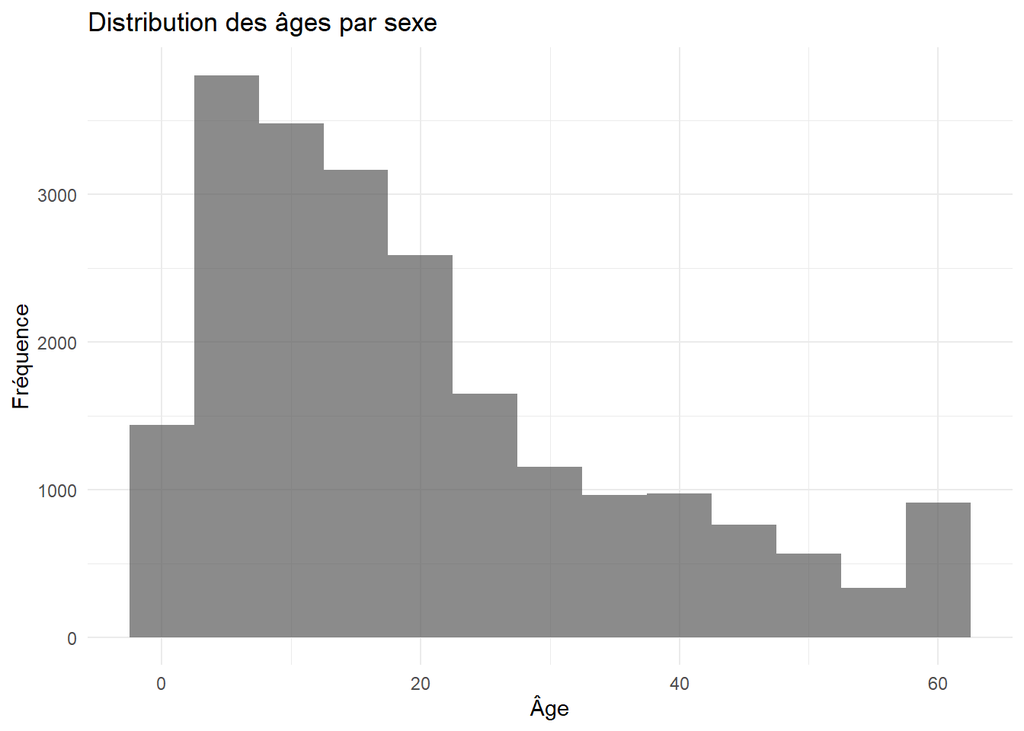

```r
Ind %>%
  filter(!is.na(ageYears), !is.na(HH_02)) %>%
  ggplot(aes(x = ageYears, fill = HH_02)) +
  geom_histogram(binwidth = 5, position = "dodge", alpha = 0.7) +
  labs(
    title = "Distribution des âges par sexe",
    x = "Âge", y = "Fréquence", fill = "Sexe"
  ) +
  theme_minimal()
```

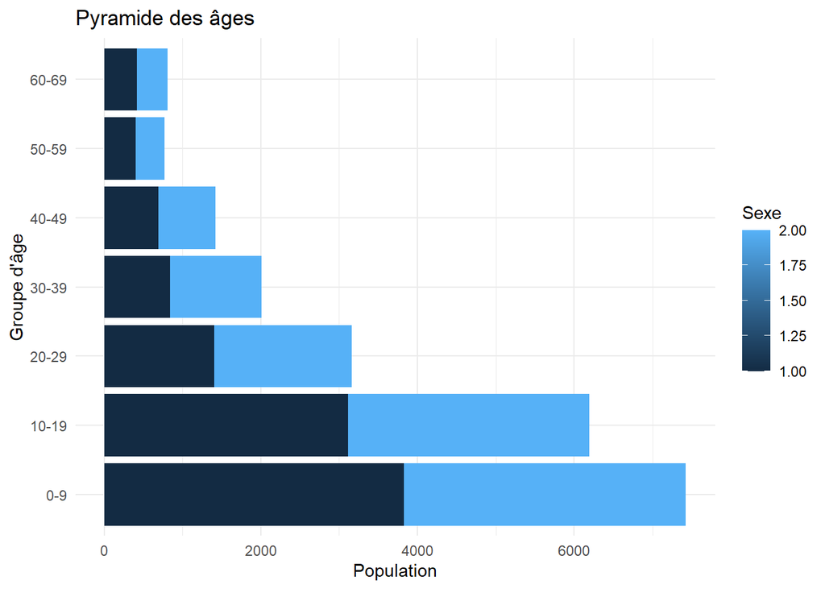

```r
Ind %>%
  filter(!is.na(ageYears), !is.na(HH_02)) %>%
  mutate(
    ageYears = as.numeric(ageYears),
    groupe_age = cut(ageYears,
                     breaks = seq(0, 100, by = 10),
                     include.lowest = TRUE,
                     labels = c("0-9", "10-19", "20-29", "30-39",
                                "40-49", "50-59", "60-69",
                                "70-79", "80-89", "90-99"))
  ) %>%
  group_by(groupe_age, HH_02) %>%
  summarise(count = n(), .groups = "drop") %>%
  ggplot(aes(
    x = groupe_age,
    y = ifelse(HH_02 == "Male", -count, count),
    fill = HH_02
  )) +
  geom_bar(stat = "identity") +
  scale_y_continuous(labels = function(x) abs(x)) +
  coord_flip() +
  labs(
    title = "Pyramide des âges",
    x = "Groupe d'âge", y = "Population", fill = "Sexe"
  ) +
  theme_minimal()
```

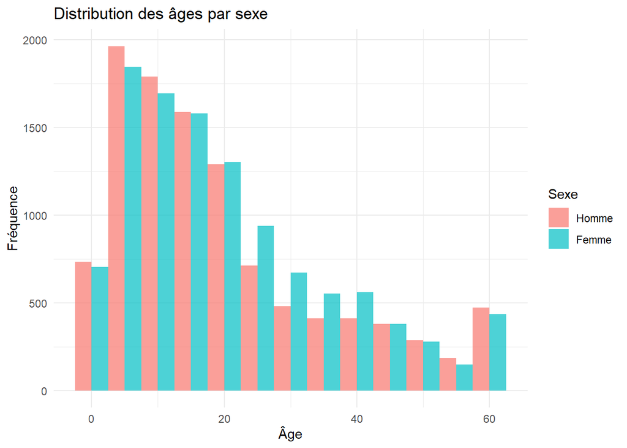

```r
# Histogramme des âges par sexe avec gestion de valeurs manquantes
Ind %>%
  filter(!is.na(ageYears), !is.na(HH_02)) %>%
  ggplot(aes(x = ageYears, fill = factor(HH_02,
                                   labels = if(any(class(Ind$HH_02) %in% c("haven_labelled", "labelled")))
                                     names(val_labels(Ind$HH_02))
                                   else c("Homme", "Femme")))) +
  geom_histogram(binwidth = 5, position = "dodge", alpha = 0.7) +
  labs(title = "Distribution des âges par sexe",
       x = "Âge", y = "Fréquence", fill = "Sexe") +
  theme_minimal()
```

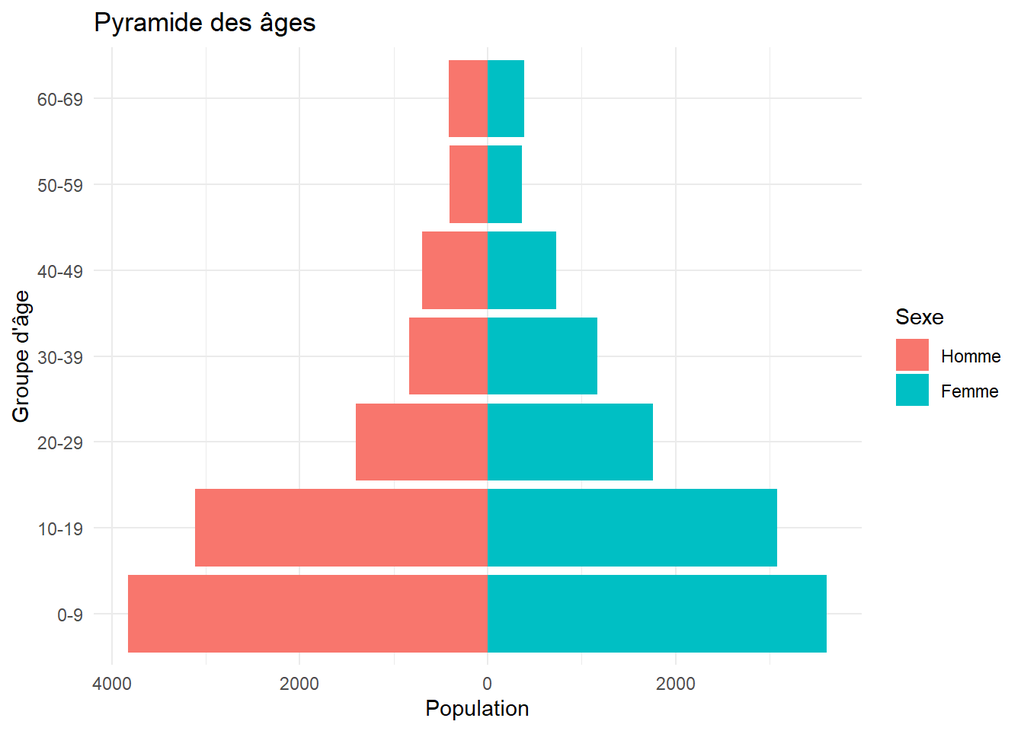

```r
# Pyramide des âges
Ind %>%
  filter(!is.na(ageYears), !is.na(HH_02)) %>%
  mutate(groupe_age = cut(ageYears, breaks = seq(0, 100, by = 10),
                         include.lowest = TRUE,
                         labels = c("0-9", "10-19", "20-29", "30-39", "40-49",
                                    "50-59", "60-69", "70-79", "80-89", "90-99"))) %>%
  group_by(groupe_age, HH_02) %>%
  summarise(count = n(), .groups = "drop") %>%
  ggplot(aes(x = groupe_age, y = ifelse(HH_02 == 1, -count, count),
             fill = factor(HH_02,
                          labels = if(any(class(Ind$HH_02) %in% c("haven_labelled", "labelled")))
                            names(val_labels(Ind$HH_02))
                          else c("Homme", "Femme")))) +
  geom_bar(stat = "identity") +
  scale_y_continuous(labels = function(x) abs(x)) +
  coord_flip() +
  labs(title = "Pyramide des âges",
       x = "Groupe d'âge", y = "Population", fill = "Sexe") +
  theme_minimal()
```

## 5.2 Analyse du niveau d’éducation

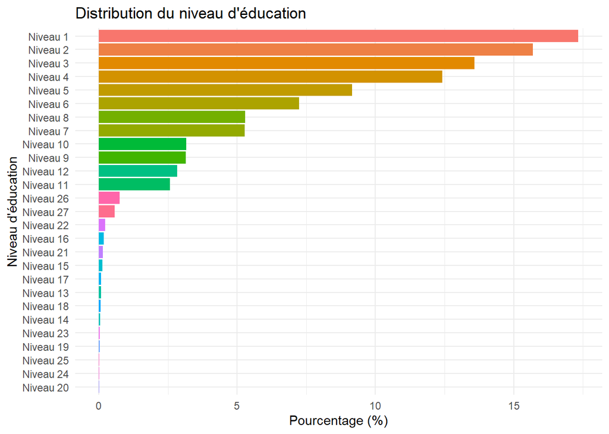

```r
# Obtention des labels d'éducation si disponibles
edu_labels <- if(any(class(Ind$HH_Educ03) %in% c("haven_labelled", "labelled")))
  names(val_labels(Ind$HH_Educ03)) else paste("Niveau", 1:length(unique(na.omit(Ind$HH_Educ03))))

# Distribution du niveau d'éducation
Ind %>%
  filter(!is.na(HH_Educ03)) %>%
  count(HH_Educ03) %>%
  mutate(pourcentage = n / sum(n) * 100) %>%
  ggplot(aes(x = reorder(factor(HH_Educ03, labels = edu_labels), n),
             y = pourcentage, fill = factor(HH_Educ03, labels = edu_labels))) +
  geom_bar(stat = "identity") +
  coord_flip() +
  labs(title = "Distribution du niveau d'éducation",
       x = "Niveau d'éducation", y = "Pourcentage (%)", fill = "Éducation") +
  theme_minimal() +
  theme(legend.position = "none")
```

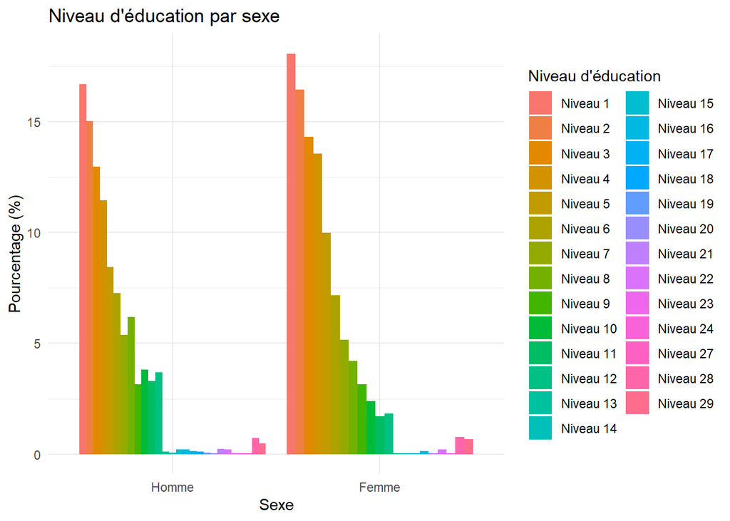

```r
# Niveau d'éducation par sexe
Ind %>%
  filter(!is.na(HH_Educ03), !is.na(HH_02)) %>%
  group_by(HH_02, HH_Educ03) %>%
  summarise(count = n(), .groups = "drop") %>%
  group_by(HH_02) %>%
  mutate(pourcentage = count / sum(count) * 100) %>%
  ggplot(aes(x = factor(HH_02,
                       labels = if(any(class(Ind$HH_02) %in% c("haven_labelled", "labelled")))
                         names(val_labels(Ind$HH_02))
                       else c("Homme", "Femme")),
            y = pourcentage,
            fill = factor(HH_Educ03,
                         labels = if(any(class(Ind$HH_Educ03) %in% c("haven_labelled", "labelled")))
                           names(val_labels(Ind$HH_Educ03))
                         else paste("Niveau", sort(unique(Ind$HH_Educ03)))))) +
  geom_bar(stat = "identity", position = "dodge") +
  labs(title = "Niveau d'éducation par sexe",
       x = "Sexe", y = "Pourcentage (%)", fill = "Niveau d'éducation") +
  theme_minimal()
```

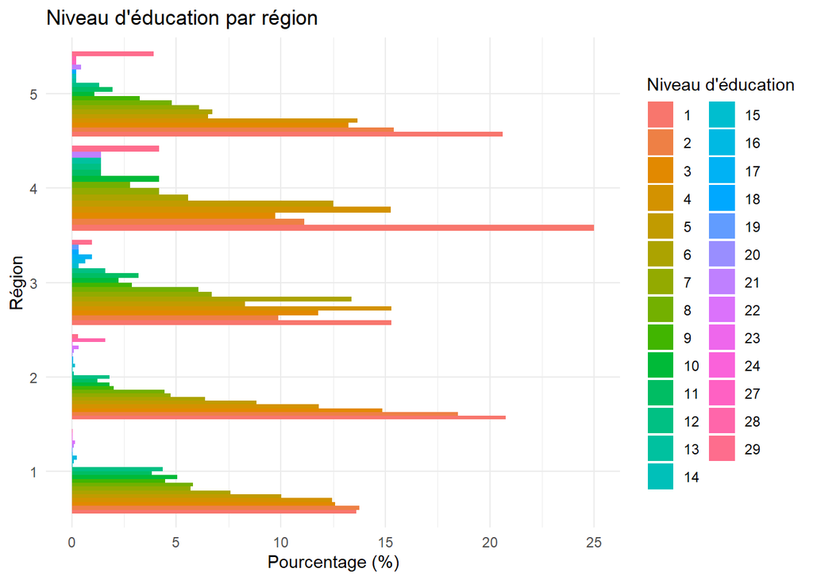

```r
# Si vous avez des variables géographiques (région, etc.), vous pourriez aussi
# analyser l'éducation par région
# Par exemple:
if("admin1" %in% names(Ind) && "HH_Educ03" %in% names(Ind)) {
  Ind %>%
    filter(!is.na(HH_Educ03), !is.na(admin1)) %>%
    group_by(admin1, HH_Educ03) %>%
    summarise(count = n(), .groups = "drop") %>%
    group_by(admin1) %>%
    mutate(pourcentage = count / sum(count) * 100) %>%
    ggplot(aes(x = factor(admin1),
               y = pourcentage,
               fill = factor(HH_Educ03))) +
    geom_bar(stat = "identity", position = "dodge") +
    labs(title = "Niveau d'éducation par région",
         x = "Région", y = "Pourcentage (%)", fill = "Niveau d'éducation") +
    theme_minimal() +
    coord_flip()
}
```

# 6 Calcul et analyse du Crowding Index (Indice d’affluence)

Le Crowding Index ou indice d’affluence est le rapport entre le nombre de personnes vivant dans un ménage et le nombre de pièces disponibles (à l’exclusion de la cuisine et des couloirs). Cet indice est un indicateur important des conditions de vie des ménages.

## 6.1 Calcul du nombre d’individus par ménage

```r
# Compter le nombre d'individus par ménage
nb_individus_par_menage <- Ind %>%
  group_by(ID) %>%
  summarise(nb_individus = n())

# Statistiques descriptives sur le nombre d'individus par ménage
summary(nb_individus_par_menage$nb_individus)
```

```
##    Min. 1st Qu.  Median    Mean 3rd Qu.    Max.
##   1.000   5.000   7.000   7.224   9.000  17.000
```

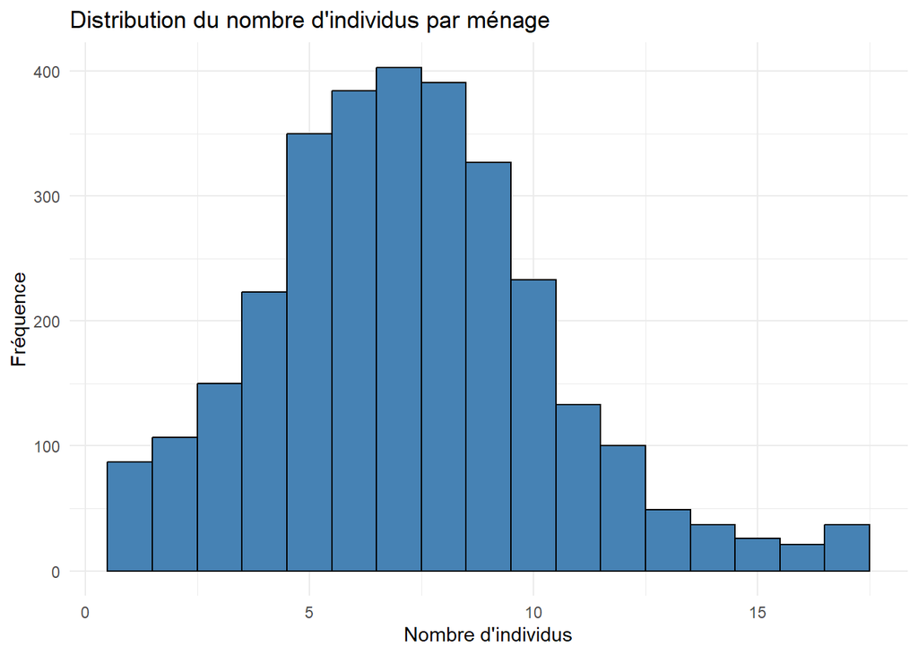

```r
# Histogramme du nombre d'individus par ménage
ggplot(nb_individus_par_menage, aes(x = nb_individus)) +
  geom_histogram(binwidth = 1, fill = "steelblue", color = "black") +
  labs(title = "Distribution du nombre d'individus par ménage",
       x = "Nombre d'individus", y = "Fréquence") +
  theme_minimal()
```

## 6.2 Statistiques descriptives sur le nombre de pièces

```r
# Statistiques descriptives sur le nombre de pièces par ménage
summary(Prin$HH14)
```

```
##    Min. 1st Qu.  Median    Mean 3rd Qu.    Max.    NA's
##   1.000   2.000   2.000   2.388   3.000  21.000       6
```

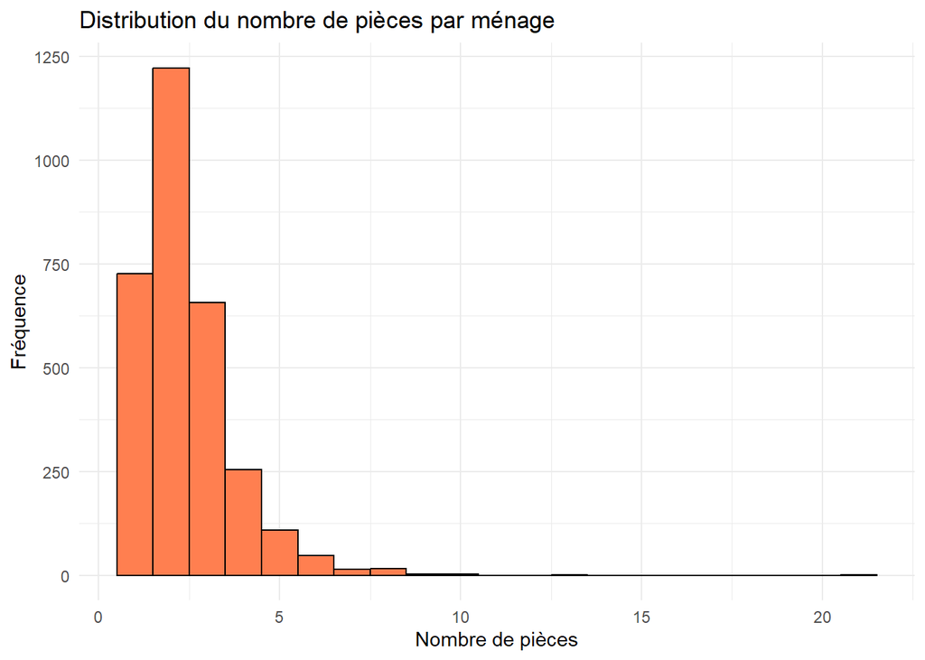

```r
# Histogramme du nombre de pièces par ménage
ggplot(Prin, aes(x = HH14)) +
  geom_histogram(binwidth = 1, fill = "coral", color = "black") +
  labs(title = "Distribution du nombre de pièces par ménage",
       x = "Nombre de pièces", y = "Fréquence") +
  theme_minimal()
```

## 6.3 Calcul de l’indice d’affluence (Crowding Index)

```r
# Joindre les données sur le nombre d'individus aux données sur les ménages
menages_avec_individus <- Prin %>%
  select(ID, HH14, Intro_07_1) %>%
  left_join(nb_individus_par_menage, by = "ID")

# Calculer l'indice d'affluence (crowding index)
menages_avec_individus <- menages_avec_individus %>%
  mutate(crowding_index = nb_individus / HH14)

# Statistiques descriptives de l'indice d'affluence
summary(menages_avec_individus$crowding_index)
```

```
##    Min. 1st Qu.  Median    Mean 3rd Qu.    Max.    NA's
##  0.1905  2.0000  3.0000  3.5997  4.5000 15.0000       6
```

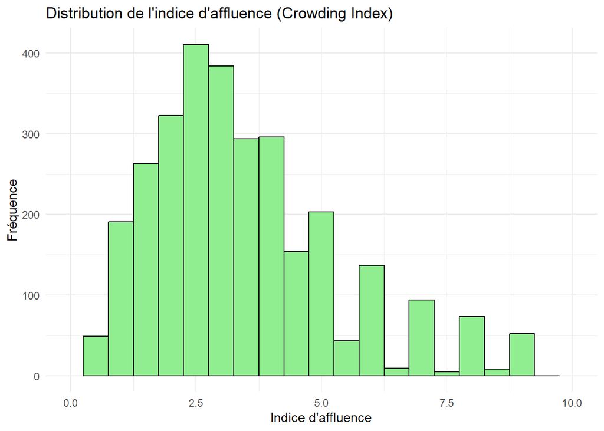

```r
# Histogramme de l'indice d'affluence
ggplot(menages_avec_individus, aes(x = crowding_index)) +
  geom_histogram(binwidth = 0.5, fill = "lightgreen", color = "black") +
  labs(title = "Distribution de l'indice d'affluence (Crowding Index)",
       x = "Indice d'affluence", y = "Fréquence") +
  theme_minimal() +
  xlim(0, 10)  # Limiter l'axe des x pour une meilleure visualisation
```

## 6.4 Analyse de la distribution de l’indice d’affluence

```r
# Catégoriser l'indice d'affluence selon les seuils demandés
menages_avec_individus <- menages_avec_individus %>%
  mutate(categorie_crowding = case_when(
    crowding_index < 1 ~ "< 1",
    crowding_index >= 1 & crowding_index < 2 ~ "1 - 2",
    crowding_index >= 2 & crowding_index < 3 ~ "2 - 3",
    crowding_index >= 3 ~ ">= 3",
    TRUE ~ NA_character_
  ))

# Calcul des proportions par catégorie
proportions_crowding <- menages_avec_individus %>%
  group_by(categorie_crowding) %>%
  summarise(n = n()) %>%
  mutate(proportion = n / sum(n) * 100)

# Affichage des proportions
proportions_crowding
```

| categorie_crowding | n | proportion |
| --- | --- | --- |
| 1 - 2 | 466 | 15.2387181 |
| 2 - 3 | 727 | 23.7737083 |
| < 1 | 61 | 1.9947678 |
| >= 3 | 1798 | 58.7965991 |
| NA | 6 | 0.1962067 |

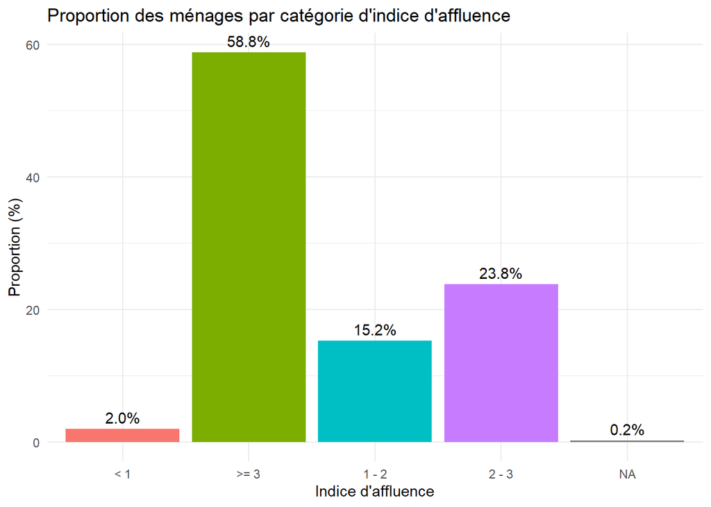

```r
# Visualisation par catégorie
ggplot(proportions_crowding, aes(x = categorie_crowding, y = proportion, fill = categorie_crowding)) +
  geom_bar(stat = "identity") +
  geom_text(aes(label = sprintf("%.1f%%", proportion)), vjust = -0.5) +
  labs(title = "Proportion des ménages par catégorie d'indice d'affluence",
       x = "Indice d'affluence", y = "Proportion (%)") +
  theme_minimal() +
  theme(legend.position = "none")
```

## 6.5 Comparaison entre réfugiés et communautés d’accueil

```r
# Obtenir les labels pour le groupe de population
if (any(class(menages_avec_individus$Intro_07_1) %in% c("haven_labelled", "labelled"))) {
  cat("Labels pour la variable groupe de population:\n")
  print(val_labels(menages_avec_individus$Intro_07_1))
}
```

```
## Labels pour la variable groupe de population:
##             Refugees       Asylum-seekers Host community North
##                    1                    2                    3
##            Returnees
##                    4
```

```r
# Analyse comparative entre réfugiés et communautés d'accueil
comparaison_par_groupe <- menages_avec_individus %>%
  group_by(Intro_07_1, categorie_crowding) %>%
  summarise(n = n(), .groups = "drop") %>%
  group_by(Intro_07_1) %>%
  mutate(proportion = n / sum(n) * 100)

# Statistiques descriptives par groupe de population
menages_avec_individus %>%
  group_by(Intro_07_1) %>%
  summarise(
    n = n(),
    moyenne = mean(crowding_index, na.rm = TRUE),
    mediane = median(crowding_index, na.rm = TRUE),
    ecart_type = sd(crowding_index, na.rm = TRUE),
    min = min(crowding_index, na.rm = TRUE),
    max = max(crowding_index, na.rm = TRUE)
  )
```

| Intro_07_1 | n | moyenne | mediane | ecart_type | min | max |
| --- | --- | --- | --- | --- | --- | --- |
| 1 | 2068 | 3.429679 | 3.000000 | 1.979161 | 0.1904762 | 15 |
| 3 | 990 | 3.954946 | 3.333333 | 2.306923 | 0.3333333 | 15 |

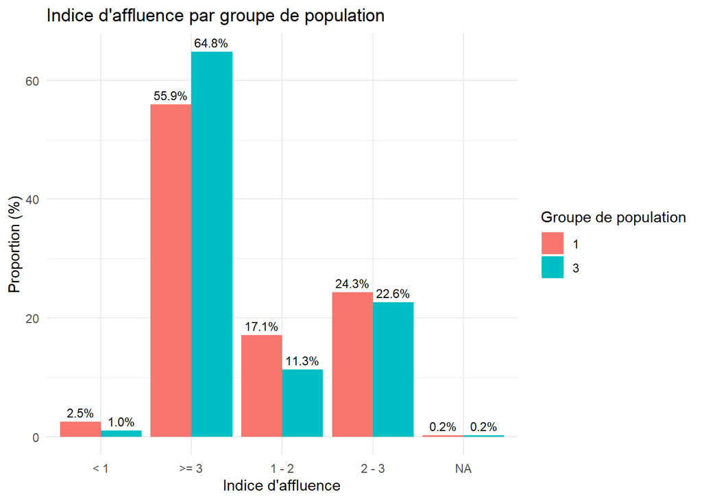

```r
# Visualisation de la comparaison
ggplot(comparaison_par_groupe, aes(x = categorie_crowding, y = proportion, fill = factor(Intro_07_1))) +
  geom_bar(stat = "identity", position = "dodge") +
  geom_text(aes(label = sprintf("%.1f%%", proportion)),
            position = position_dodge(width = 0.9), vjust = -0.5, size = 3) +
  labs(title = "Indice d'affluence par groupe de population",
       x = "Indice d'affluence", y = "Proportion (%)", fill = "Groupe de population") +
  theme_minimal()
```

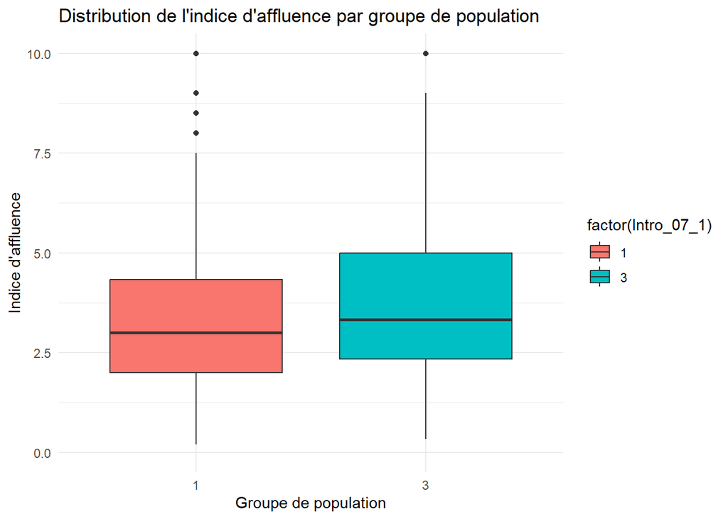

```r
# Boîte à moustaches pour comparer les distributions
ggplot(menages_avec_individus, aes(x = factor(Intro_07_1), y = crowding_index, fill = factor(Intro_07_1))) +
  geom_boxplot() +
  labs(title = "Distribution de l'indice d'affluence par groupe de population",
       x = "Groupe de population", y = "Indice d'affluence") +
  theme_minimal() +
  ylim(0, 10)  # Limiter l'axe des y pour une meilleure visualisation
```

# 7 Analyse de la sécurité alimentaire des déplacés internes

## 7.1 Score de Consommation Alimentaire (SCA)

Le Score de Consommation Alimentaire (SCA) est un indicateur proxy développé par le Programme Alimentaire Mondial pour mesurer la sécurité alimentaire des ménages. C’est un score composite basé sur la diversité alimentaire, la fréquence de consommation et l’importance nutritionnelle relative des groupes d’aliments consommés.

### 7.1.1 Analyse descriptive des variables composant le SCA

```r
# Identifier les variables pertinentes pour le SCA
variables_sca <- c(
  "Food_div1",    # Céréales, grains, racines et tubercules
  "Food_div2",    # Légumineuses/haricots
  "Food_div3",    # Lait et produits laitiers
  "Food_div4",    # Viande, poisson et œufs (composite)
  "Food_div5",    # Légumes
  "Food_div6",    # Fruits
  "Food_div7",    # Huile/graisse
  "Food_div8"     # Sucre
)

# Créer un dataframe contenant uniquement les variables du SCA
sca_data <- Prin %>%
  select(ID, Intro_07_1, admin1, admin2, all_of(variables_sca))

# Statistiques descriptives pour chaque variable
sca_stats <- sca_data %>%
  summarise(across(all_of(variables_sca),
                   list(
                     moyenne = ~mean(., na.rm = TRUE),
                     mediane = ~median(., na.rm = TRUE),
                     ecart_type = ~sd(., na.rm = TRUE),
                     min = ~min(., na.rm = TRUE),
                     max = ~max(., na.rm = TRUE),
                     n_valides = ~sum(!is.na(.)),
                     n_manquants = ~sum(is.na(.))
                   )))

# Afficher les statistiques
sca_stats %>%
  pivot_longer(cols = everything(),
               names_to = c("variable", "stat"),
               names_pattern = "(.*)_(.*)") %>%
  pivot_wider(names_from = stat, values_from = value) %>%
  knitr::kable(caption = "Statistiques descriptives des variables du SCA")
```

Statistiques descriptives des variables du SCA

| variable | moyenne | mediane | type | min | max | valides | manquants |
| --- | --- | --- | --- | --- | --- | --- | --- |
| Food_div1 | 3.2213491 | 3 | NA | 0 | 7 | NA | NA |
| Food_div1_ecart | NA | NA | 2.640259 | NA | NA | NA | NA |
| Food_div1_n | NA | NA | NA | NA | NA | 3054 | 4 |
| Food_div2 | 1.1100917 | 0 | NA | 0 | 7 | NA | NA |
| Food_div2_ecart | NA | NA | 1.843696 | NA | NA | NA | NA |
| Food_div2_n | NA | NA | NA | NA | NA | 3052 | 6 |
| Food_div3 | 0.5188463 | 0 | NA | 0 | 7 | NA | NA |
| Food_div3_ecart | NA | NA | 1.404870 | NA | NA | NA | NA |
| Food_div3_n | NA | NA | NA | NA | NA | 3051 | 7 |
| Food_div4 | 0.6148294 | 0 | NA | 0 | 7 | NA | NA |
| Food_div4_ecart | NA | NA | 1.280462 | NA | NA | NA | NA |
| Food_div4_n | NA | NA | NA | NA | NA | 3048 | 10 |
| Food_div5 | 0.9244167 | 0 | NA | 0 | 7 | NA | NA |
| Food_div5_ecart | NA | NA | 1.746097 | NA | NA | NA | NA |
| Food_div5_n | NA | NA | NA | NA | NA | 3043 | 15 |
| Food_div6 | 0.2994740 | 0 | NA | 0 | 7 | NA | NA |
| Food_div6_ecart | NA | NA | 1.139148 | NA | NA | NA | NA |
| Food_div6_n | NA | NA | NA | NA | NA | 3042 | 16 |
| Food_div7 | 1.0223170 | 0 | NA | 0 | 7 | NA | NA |
| Food_div7_ecart | NA | NA | 1.907796 | NA | NA | NA | NA |
| Food_div7_n | NA | NA | NA | NA | NA | 3047 | 11 |
| Food_div8 | 0.8103222 | 0 | NA | 0 | 7 | NA | NA |
| Food_div8_ecart | NA | NA | 1.739492 | NA | NA | NA | NA |
| Food_div8_n | NA | NA | NA | NA | NA | 3042 | 16 |

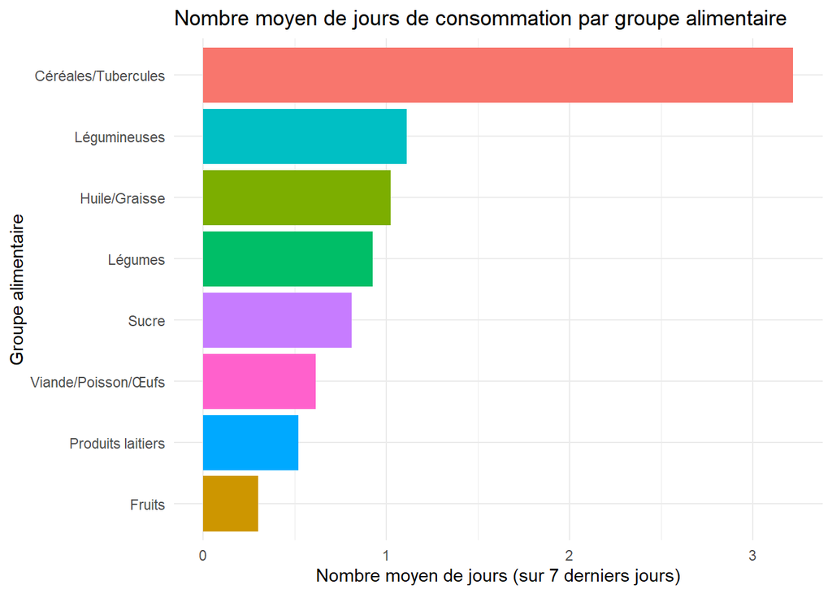

```r
# Visualisation de la fréquence de consommation moyenne pour chaque groupe d'aliments
sca_data %>%
  pivot_longer(cols = all_of(variables_sca),
               names_to = "groupe_alimentaire",
               values_to = "jours_consommation") %>%
  group_by(groupe_alimentaire) %>%
  summarise(jours_moyens = mean(jours_consommation, na.rm = TRUE)) %>%
  mutate(groupe_alimentaire = case_when(
    groupe_alimentaire == "Food_div1" ~ "Céréales/Tubercules",
    groupe_alimentaire == "Food_div2" ~ "Légumineuses",
    groupe_alimentaire == "Food_div3" ~ "Produits laitiers",
    groupe_alimentaire == "Food_div4" ~ "Viande/Poisson/Œufs",
    groupe_alimentaire == "Food_div5" ~ "Légumes",
    groupe_alimentaire == "Food_div6" ~ "Fruits",
    groupe_alimentaire == "Food_div7" ~ "Huile/Graisse",
    groupe_alimentaire == "Food_div8" ~ "Sucre",
    TRUE ~ groupe_alimentaire
  )) %>%
  ggplot(aes(x = reorder(groupe_alimentaire, jours_moyens), y = jours_moyens, fill = groupe_alimentaire)) +
  geom_bar(stat = "identity") +
  coord_flip() +
  labs(title = "Nombre moyen de jours de consommation par groupe alimentaire",
       x = "Groupe alimentaire",
       y = "Nombre moyen de jours (sur 7 derniers jours)") +
  theme_minimal() +
  theme(legend.position = "none")
```

### 7.1.2 Calcul du Score de Consommation Alimentaire

```r
# Tableau des poids attribués à chaque groupe alimentaire
poids_sca <- data.frame(
  groupe_alimentaire = c("Céréales/Tubercules", "Légumineuses", "Produits laitiers",
                         "Viande/Poisson/Œufs", "Légumes", "Fruits",
                         "Huile/Graisse", "Sucre"),
  variable = c("Food_div1", "Food_div2", "Food_div3",
               "Food_div4", "Food_div5", "Food_div6",
               "Food_div7", "Food_div8"),
  poids = c(2, 3, 4, 4, 1, 1, 0.5, 0.5)
)

# Afficher le tableau des poids
knitr::kable(poids_sca, caption = "Poids attribués aux groupes alimentaires pour le calcul du SCA")
```

Poids attribués aux groupes alimentaires pour le calcul du SCA

| groupe_alimentaire | variable | poids |
| --- | --- | --- |
| Céréales/Tubercules | Food_div1 | 2.0 |
| Légumineuses | Food_div2 | 3.0 |
| Produits laitiers | Food_div3 | 4.0 |
| Viande/Poisson/Œufs | Food_div4 | 4.0 |
| Légumes | Food_div5 | 1.0 |
| Fruits | Food_div6 | 1.0 |
| Huile/Graisse | Food_div7 | 0.5 |
| Sucre | Food_div8 | 0.5 |

```r
# Calculer le SCA pour chaque ménage
sca_data <- sca_data %>%
  mutate(
    sca_cereales = Food_div1 * 2,
    sca_legumineuses = Food_div2 * 3,
    sca_lait = Food_div3 * 4,
    sca_viande = Food_div4 * 4,
    sca_legumes = Food_div5 * 1,
    sca_fruits = Food_div6 * 1,
    sca_huile = Food_div7 * 0.5,
    sca_sucre = Food_div8 * 0.5,
    sca_total = sca_cereales + sca_legumineuses + sca_lait + sca_viande +
                sca_legumes + sca_fruits + sca_huile + sca_sucre
  )

# Statistiques descriptives du SCA
summary(sca_data$sca_total)
```

```
##    Min. 1st Qu.  Median    Mean 3rd Qu.    Max.    NA's
##    0.00    6.00   14.00   16.46   23.00  107.00      23
```

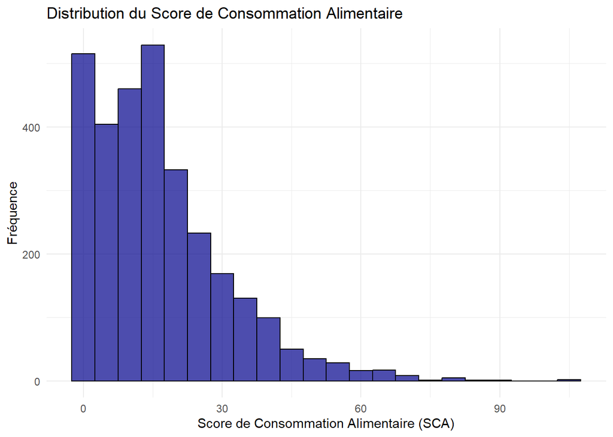

```r
# Histogramme du SCA
ggplot(sca_data, aes(x = sca_total)) +
  geom_histogram(binwidth = 5, fill = "darkblue", color = "black", alpha = 0.7) +
  labs(title = "Distribution du Score de Consommation Alimentaire",
       x = "Score de Consommation Alimentaire (SCA)",
       y = "Fréquence") +
  theme_minimal()
```

### 7.1.3 Catégorisation du SCA selon différents seuils

```r
# Catégoriser le SCA selon les seuils 21/35
sca_data <- sca_data %>%
  mutate(
    categorie_sca_21_35 = case_when(
      sca_total < 21 ~ "Pauvre",
      sca_total >= 21 & sca_total <= 35 ~ "Limite",
      sca_total > 35 ~ "Acceptable",
      TRUE ~ NA_character_
    )
  )

# Catégoriser le SCA selon les seuils 28/42
sca_data <- sca_data %>%
  mutate(
    categorie_sca_28_42 = case_when(
      sca_total < 28 ~ "Pauvre",
      sca_total >= 28 & sca_total <= 42 ~ "Limite",
      sca_total > 42 ~ "Acceptable",
      TRUE ~ NA_character_
    )
  )

# Proportions selon les seuils 21/35
prop_sca_21_35 <- sca_data %>%
  group_by(categorie_sca_21_35) %>%
  summarise(n = n()) %>%
  mutate(proportion = n / sum(n) * 100)

# Proportions selon les seuils 28/42
prop_sca_28_42 <- sca_data %>%
  group_by(categorie_sca_28_42) %>%
  summarise(n = n()) %>%
  mutate(proportion = n / sum(n) * 100)

# Afficher les résultats
knitr::kable(prop_sca_21_35, caption = "Répartition des ménages selon les seuils SCA 21/35")
```

Répartition des ménages selon les seuils SCA 21/35

| categorie_sca_21_35 | n | proportion |
| --- | --- | --- |
| Acceptable | 311 | 10.1700458 |
| Limite | 626 | 20.4708960 |
| Pauvre | 2098 | 68.6069326 |
| NA | 23 | 0.7521256 |

```r
knitr::kable(prop_sca_28_42, caption = "Répartition des ménages selon les seuils SCA 28/42")
```

Répartition des ménages selon les seuils SCA 28/42

| categorie_sca_28_42 | n | proportion |
| --- | --- | --- |
| Acceptable | 169 | 5.5264879 |
| Limite | 393 | 12.8515370 |
| Pauvre | 2473 | 80.8698496 |
| NA | 23 | 0.7521256 |

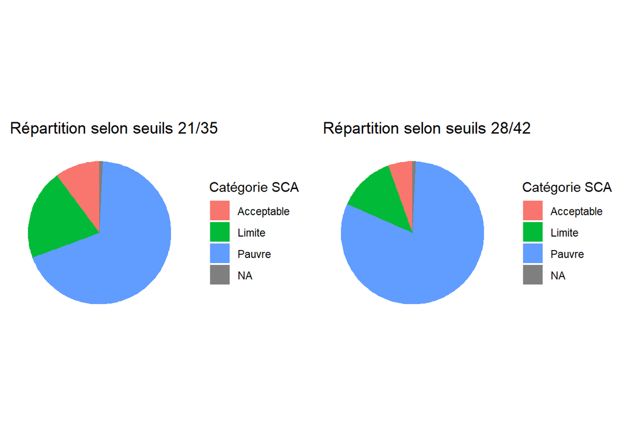

```r
# Visualisation des catégories selon les deux seuils
par(mfrow=c(1,2))
# Graphique pour les seuils 21/35
p1 <- ggplot(prop_sca_21_35, aes(x = "", y = proportion, fill = categorie_sca_21_35)) +
  geom_bar(stat = "identity", width = 1) +
  coord_polar("y", start = 0) +
  labs(title = "Répartition selon seuils 21/35",
       fill = "Catégorie SCA") +
  theme_minimal() +
  theme(axis.text = element_blank(),
        axis.title = element_blank(),
        panel.grid = element_blank())

# Graphique pour les seuils 28/42
p2 <- ggplot(prop_sca_28_42, aes(x = "", y = proportion, fill = categorie_sca_28_42)) +
  geom_bar(stat = "identity", width = 1) +
  coord_polar("y", start = 0) +
  labs(title = "Répartition selon seuils 28/42",
       fill = "Catégorie SCA") +
  theme_minimal() +
  theme(axis.text = element_blank(),
        axis.title = element_blank(),
        panel.grid = element_blank())

# Afficher les deux graphiques côte à côte
gridExtra::grid.arrange(p1, p2, ncol = 2)
```

### 7.1.4 Représentation spatiale du SCA par région et département

```r
# Vérifier les labels pour admin1 et admin2
if (any(class(sca_data$admin1) %in% c("haven_labelled", "labelled"))) {
  cat("Labels pour admin1 (Région):\n")
  print(val_labels(sca_data$admin1))
}
```

```
## Labels pour admin1 (Région):
##             Unity        Upper Nile Central Equatoria           Jonglei
##                 1                 2                 3                 4
## Western Equatoria Eastern Equatoria
##                 5                 6
```

```r
if (any(class(sca_data$admin2) %in% c("haven_labelled", "labelled"))) {
  cat("Labels pour admin2 (Département):\n")
  print(val_labels(sca_data$admin2))
}
```

```
## Labels pour admin2 (Département):
##  Pariang    Maban     Juba   Morobo      Yei Pochalla      Ezo   Maridi
##        1        2        3        4        5        6        7        8
##  Tambura   Yambio    Magwi     Juba
##        9       10       11       12
```

```r
# Statistiques par région (admin1)
stats_par_region <- sca_data %>%
  group_by(admin1) %>%
  summarise(
    sca_moyen = mean(sca_total, na.rm = TRUE),
    sca_median = median(sca_total, na.rm = TRUE),
    n = n(),
    pct_pauvre_21_35 = mean(categorie_sca_21_35 == "Pauvre", na.rm = TRUE) * 100,
    pct_limite_21_35 = mean(categorie_sca_21_35 == "Limite", na.rm = TRUE) * 100,
    pct_acceptable_21_35 = mean(categorie_sca_21_35 == "Acceptable", na.rm = TRUE) * 100
  )

# Statistiques par département (admin2)
stats_par_departement <- sca_data %>%
  group_by(admin1, admin2) %>%
  summarise(
    sca_moyen = mean(sca_total, na.rm = TRUE),
    sca_median = median(sca_total, na.rm = TRUE),
    n = n(),
    pct_pauvre_21_35 = mean(categorie_sca_21_35 == "Pauvre", na.rm = TRUE) * 100,
    pct_limite_21_35 = mean(categorie_sca_21_35 == "Limite", na.rm = TRUE) * 100,
    pct_acceptable_21_35 = mean(categorie_sca_21_35 == "Acceptable", na.rm = TRUE) * 100,
    .groups = "drop"
  )

# Afficher les résultats par région
knitr::kable(stats_par_region,
             caption = "Score de Consommation Alimentaire par région",
             digits = 1)
```

Score de Consommation Alimentaire par région

| admin1 | sca_moyen | sca_median | n | pct_pauvre_21_35 | pct_limite_21_35 | pct_acceptable_21_35 |
| --- | --- | --- | --- | --- | --- | --- |
| 1 | 16.8 | 14.0 | 1064 | 69.9 | 22.6 | 7.5 |
| 2 | 14.5 | 10.2 | 1466 | 74.5 | 15.1 | 10.5 |
| 3 | 27.3 | 25.0 | 114 | 34.5 | 36.3 | 29.2 |
| 4 | 8.0 | 7.0 | 35 | 96.4 | 3.6 | 0.0 |
| 5 | 21.4 | 20.5 | 285 | 50.2 | 36.8 | 13.0 |
| NA | 18.0 | 14.5 | 94 | 68.5 | 21.7 | 9.8 |

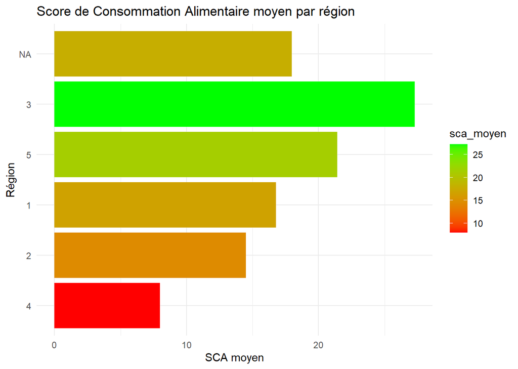

```r
# Visualisation du SCA moyen par région
ggplot(stats_par_region, aes(x = reorder(as.factor(admin1), sca_moyen), y = sca_moyen, fill = sca_moyen)) +
  geom_bar(stat = "identity") +
  coord_flip() +
  scale_fill_gradient(low = "red", high = "green") +
  labs(title = "Score de Consommation Alimentaire moyen par région",
       x = "Région",
       y = "SCA moyen") +
  theme_minimal()
```

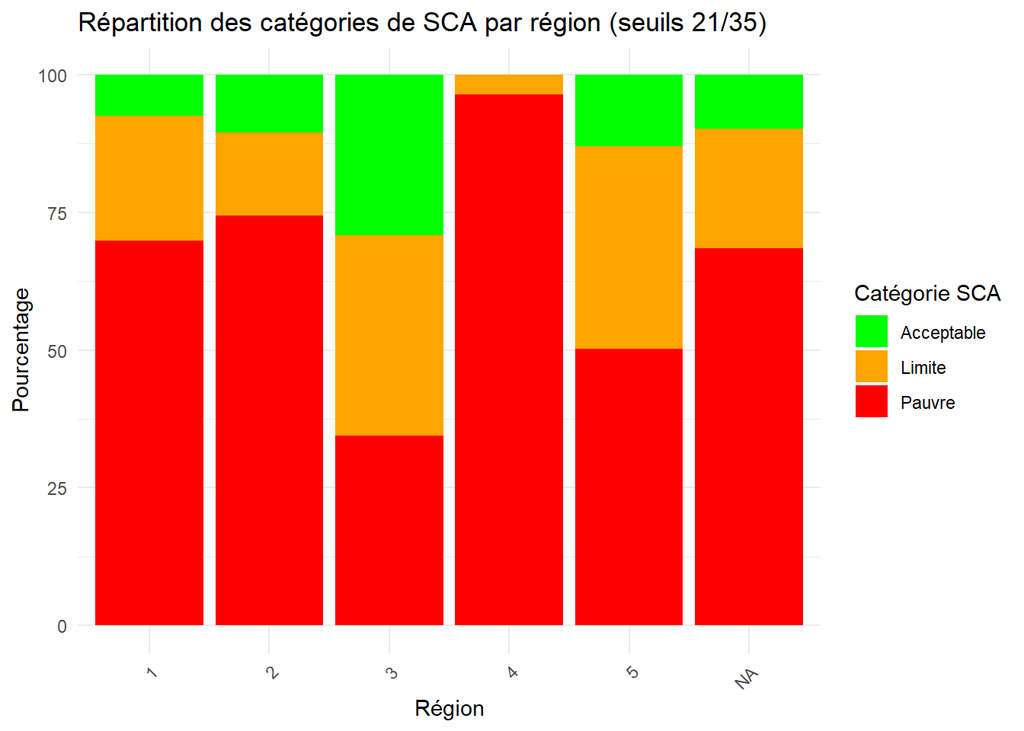

```r
# Visualisation des catégories de SCA par région
stats_par_region_long <- stats_par_region %>%
  select(admin1, pct_pauvre_21_35, pct_limite_21_35, pct_acceptable_21_35) %>%
  pivot_longer(cols = starts_with("pct_"),
               names_to = "categorie",
               values_to = "pourcentage") %>%
  mutate(categorie = case_when(
    categorie == "pct_pauvre_21_35" ~ "Pauvre",
    categorie == "pct_limite_21_35" ~ "Limite",
    categorie == "pct_acceptable_21_35" ~ "Acceptable",
    TRUE ~ categorie
  ))

ggplot(stats_par_region_long, aes(x = as.factor(admin1), y = pourcentage, fill = categorie)) +
  geom_bar(stat = "identity", position = "stack") +
  scale_fill_manual(values = c("Pauvre" = "red", "Limite" = "orange", "Acceptable" = "green")) +
  labs(title = "Répartition des catégories de SCA par région (seuils 21/35)",
       x = "Région",
       y = "Pourcentage",
       fill = "Catégorie SCA") +
  theme_minimal() +
  theme(axis.text.x = element_text(angle = 45, hjust = 1))
```

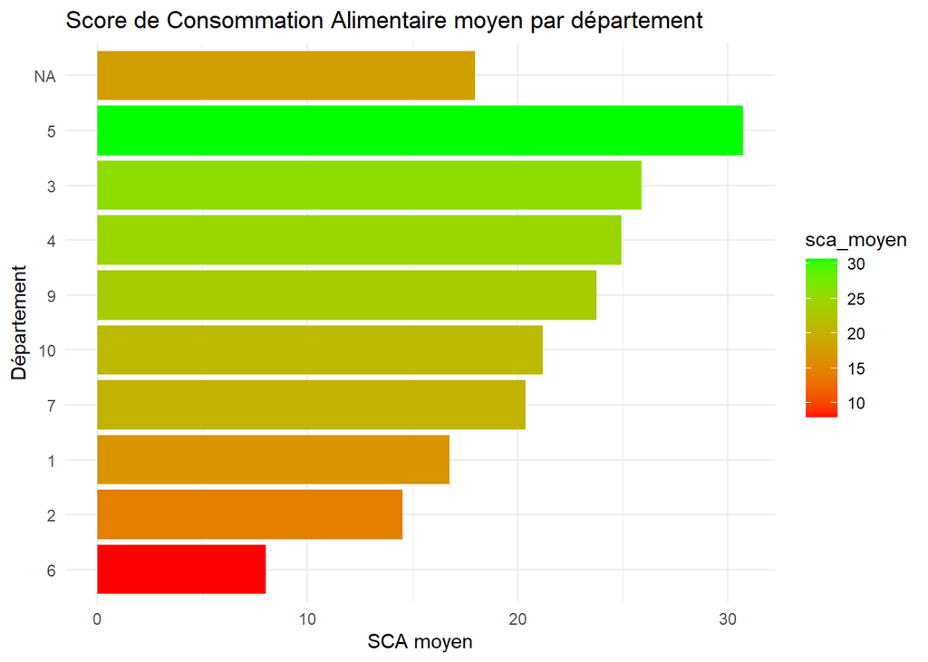

```r
# Si le nombre de départements est élevé, limiter l'affichage aux principaux départements
if (nrow(stats_par_departement) > 15) {
  top_departements <- stats_par_departement %>%
    arrange(desc(n)) %>%
    head(15)

  ggplot(top_departements, aes(x = reorder(as.factor(admin2), sca_moyen), y = sca_moyen, fill = sca_moyen)) +
    geom_bar(stat = "identity") +
    coord_flip() +
    scale_fill_gradient(low = "red", high = "green") +
    labs(title = "Score de Consommation Alimentaire moyen par département (top 15)",
         x = "Département",
         y = "SCA moyen") +
    theme_minimal()
} else {
  ggplot(stats_par_departement, aes(x = reorder(as.factor(admin2), sca_moyen), y = sca_moyen, fill = sca_moyen)) +
    geom_bar(stat = "identity") +
    coord_flip() +
    scale_fill_gradient(low = "red", high = "green") +
    labs(title = "Score de Consommation Alimentaire moyen par département",
         x = "Département",
         y = "SCA moyen") +
    theme_minimal()
}
```

### 7.1.5 Analyse du SCA selon le statut de déplacement

```r
# Analyse du SCA selon le groupe de population (réfugiés vs. communautés d'accueil)
stats_par_statut <- sca_data %>%
  group_by(Intro_07_1) %>%
  summarise(
    sca_moyen = mean(sca_total, na.rm = TRUE),
    sca_median = median(sca_total, na.rm = TRUE),
    sca_ecart_type = sd(sca_total, na.rm = TRUE),
    n = n(),
    pct_pauvre_21_35 = mean(categorie_sca_21_35 == "Pauvre", na.rm = TRUE) * 100,
    pct_limite_21_35 = mean(categorie_sca_21_35 == "Limite", na.rm = TRUE) * 100,
    pct_acceptable_21_35 = mean(categorie_sca_21_35 == "Acceptable", na.rm = TRUE) * 100
  )

# Afficher les résultats par statut de déplacement
knitr::kable(stats_par_statut,
             caption = "Score de Consommation Alimentaire par statut de déplacement",
             digits = 1)
```

Score de Consommation Alimentaire par statut de déplacement

| Intro_07_1 | sca_moyen | sca_median | sca_ecart_type | n | pct_pauvre_21_35 | pct_limite_21_35 | pct_acceptable_21_35 |
| --- | --- | --- | --- | --- | --- | --- | --- |
| 1 | 16.4 | 14 | 14.2 | 2068 | 67.5 | 22.5 | 10.0 |
| 3 | 16.6 | 14 | 14.6 | 990 | 72.4 | 16.8 | 10.8 |

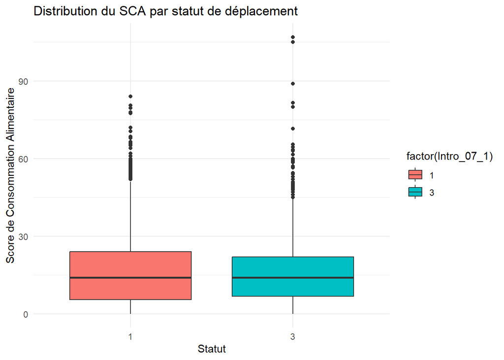

```r
# Boîte à moustaches du SCA par statut de déplacement
ggplot(sca_data, aes(x = factor(Intro_07_1), y = sca_total, fill = factor(Intro_07_1))) +
  geom_boxplot() +
  labs(title = "Distribution du SCA par statut de déplacement",
       x = "Statut",
       y = "Score de Consommation Alimentaire") +
  theme_minimal()
```

```r
# Test statistique pour comparer les moyennes (si plus de 2 groupes)
if (length(unique(na.omit(sca_data$Intro_07_1))) > 1) {
  cat("Test ANOVA pour comparer les moyennes du SCA entre les groupes:\n")
  print(summary(aov(sca_total ~ factor(Intro_07_1), data = sca_data)))
}
```

```
## Test ANOVA pour comparer les moyennes du SCA entre les groupes:
##                      Df Sum Sq Mean Sq F value Pr(>F)
## factor(Intro_07_1)    1     19   18.53   0.091  0.764
## Residuals          3033 620829  204.69
## 23 observations effacées parce que manquantes
```

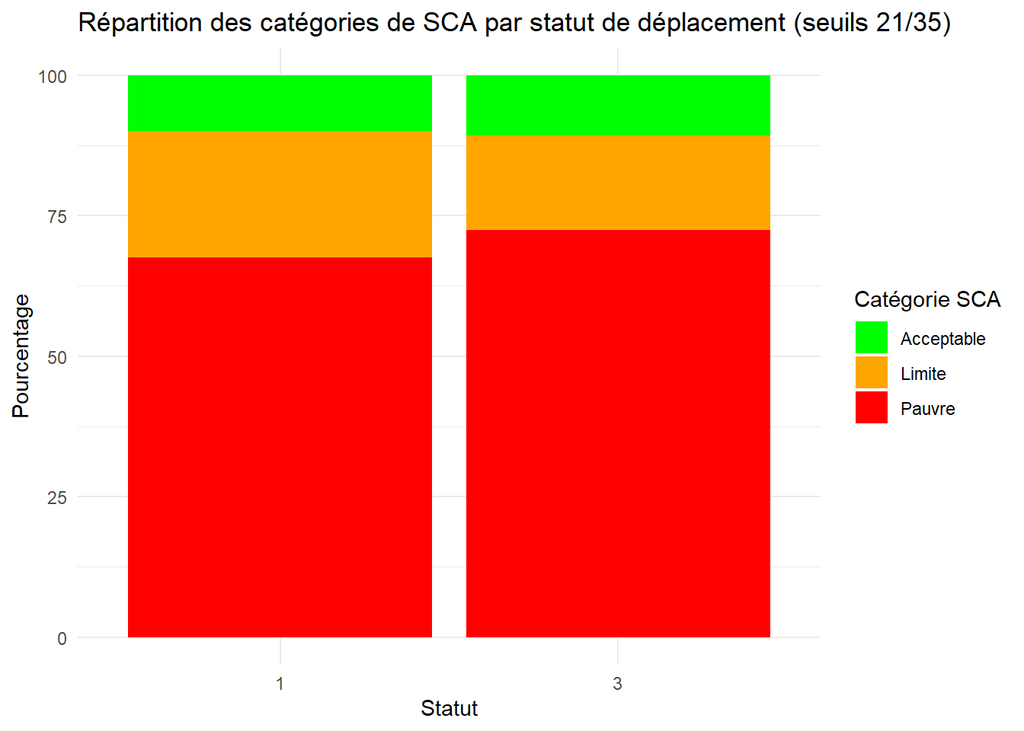

```r
# Tableau croisé des catégories SCA par statut de déplacement
tableau_croise <- table(sca_data$Intro_07_1, sca_data$categorie_sca_21_35)
prop_tableau <- prop.table(tableau_croise, margin = 1) * 100

# Convertir en dataframe pour ggplot
df_tableau <- as.data.frame(prop_tableau)
colnames(df_tableau) <- c("Statut", "Categorie_SCA", "Proportion")

# Graphique à barres empilées
ggplot(df_tableau, aes(x = Statut, y = Proportion, fill = Categorie_SCA)) +
  geom_bar(stat = "identity", position = "stack") +
  scale_fill_manual(values = c("Pauvre" = "red", "Limite" = "orange", "Acceptable" = "green")) +
  labs(title = "Répartition des catégories de SCA par statut de déplacement (seuils 21/35)",
       x = "Statut",
       y = "Pourcentage",
       fill = "Catégorie SCA") +
  theme_minimal()
```

### 7.1.6 Analyse spatiale dU SCA

```r
# Calcul du SCA comme dans votre code
sca_data <- Prin %>%
  mutate(
    sca_total = (Food_div1*2) + (Food_div2*3) + (Food_div3*4) +
                (Food_div4*4) + (Food_div5*1) + (Food_div6*1) +
                (Food_div7*0.5) + (Food_div8*0.5),
    categorie_sca = case_when(
      sca_total < 21 ~ "Pauvre",
      sca_total >= 21 & sca_total <= 35 ~ "Limite",
      sca_total > 35 ~ "Acceptable"
    )
  )
```

```r
# Calcul du SCA comme dans votre code
sca_data <- Prin %>%
  mutate(
    sca_total = (Food_div1*2) + (Food_div2*3) + (Food_div3*4) +
                (Food_div4*4) + (Food_div5*1) + (Food_div6*1) +
                (Food_div7*0.5) + (Food_div8*0.5),
    categorie_sca = case_when(
      sca_total < 21 ~ "Pauvre",
      sca_total >= 21 & sca_total <= 35 ~ "Limite",
      sca_total > 35 ~ "Acceptable"
    )
  )
```

```r
# Agrégation par région
sca_region <- sca_data %>%
  group_by(admin1) %>%
  summarise(
    sca_moyen = mean(sca_total, na.rm = TRUE),
    pct_pauvre = mean(categorie_sca == "Pauvre", na.rm = TRUE)*100,
    pct_limite = mean(categorie_sca == "Limite", na.rm = TRUE)*100,
    pct_acceptable = mean(categorie_sca == "Acceptable", na.rm = TRUE)*100
  )
```

```r
# Nettoyage des clés géographiques
Prin <- Prin %>%
  mutate(
    admin1_clean = tolower(trimws(admin1)),
    admin2_clean = tolower(trimws(admin2)),
    admin3_clean = tolower(trimws(admin3))
  )
```

```r
# 2. Identifier les colonnes nécessaires pour calculer le SCA
# (D'après votre description précédente, les variables sont Food_div1 à Food_div8)
variables_sca <- c("Food_div1", "Food_div2", "Food_div3", "Food_div4",
                   "Food_div5", "Food_div6", "Food_div7", "Food_div8")

# 3. Calculer le SCA si les colonnes existent
if(all(variables_sca %in% names(Prin))) {
  Prin <- Prin %>%
    mutate(
      sca_total = (Food_div1*2) + (Food_div2*3) + (Food_div3*4) +
                  (Food_div4*4) + (Food_div5*1) + (Food_div6*1) +
                  (Food_div7*0.5) + (Food_div8*0.5)
    )
} else {
  stop("Colonnes manquantes pour calculer le SCA")
}
```

```r
admin2_sf <- st_read("../Donnees/sdn_adm_cbs_nic_ssa_20200831_shp/sdn_admbnda_adm2_cbs_nic_ssa_20200831.shp")  %>%
  mutate(admin2_clean = tolower(ADM2_EN))
donnees_admin2 <- Prin %>%
  group_by(admin2_clean) %>%
  summarise(sca_moyen = mean(sca_total, na.rm = TRUE)) %>%
  left_join(admin2_sf, ., by = "admin2_clean")
```

```r
# 0. Vérification des colonnes disponibles
print("Voici les noms des colonnes disponibles dans votre jeu de données:")
```

```
## [1] "Voici les noms des colonnes disponibles dans votre jeu de données:"
```

```r
print(colnames(donnees_admin2))
```

```
##  [1] "Shape_Leng"   "Shape_Area"   "ADM2_EN"      "ADM2_AR"      "ADM2_PCODE"
##  [6] "ADM2_REF"     "ADM2ALT1EN"   "ADM2ALT2EN"   "ADM2ALT1AR"   "ADM2ALT2AR"
## [11] "ADM1_EN"      "ADM1_AR"      "ADM1_PCODE"   "ADM0_EN"      "ADM0_AR"
## [16] "ADM0_PCODE"   "date"         "validOn"      "validTo"      "admin2_clean"
## [21] "sca_moyen"    "geometry"
```

```r
### 1. Préparation des données ###
donnees_admin2 <- donnees_admin2 %>%
  mutate(
    # Conversion sécurisée des valeurs
    sca_moyen_num = as.numeric(as.character(sca_moyen)),

    # Catégorisation SCA
    categorie_sca = case_when(
      sca_moyen_num < 21 ~ "Pauvre (<21)",
      sca_moyen_num >= 21 & sca_moyen_num <= 35 ~ "Limite (21-35)",
      sca_moyen_num > 35 ~ "Acceptable (>35)",
      is.na(sca_moyen_num) ~ "Donnée manquante"
    )
  )

# Création des étiquettes en fonction des colonnes disponibles
# Nous utiliserons une approche conditionnelle pour inclure les indicateurs
# seulement s'ils existent dans les données

# Vérifier si les colonnes d'indicateurs existent
has_food_div1 <- "Food_div1" %in% colnames(donnees_admin2)
has_food_div2 <- "Food_div2" %in% colnames(donnees_admin2)
has_food_div3 <- "Food_div3" %in% colnames(donnees_admin2)
has_food_div4 <- "Food_div4" %in% colnames(donnees_admin2)

# Chercher des colonnes alternatives qui pourraient contenir les mêmes informations
# (par exemple, avec des noms légèrement différents)
food_cols <- grep("cereal|céréal|legum|légum|viande|poisson|meat|fish|dairy|lait",
                 colnames(donnees_admin2),
                 ignore.case = TRUE,
                 value = TRUE)

print("Colonnes potentiellement liées à l'alimentation trouvées:")
```

```
## [1] "Colonnes potentiellement liées à l'alimentation trouvées:"
```

```r
print(food_cols)
```

```
## character(0)
```

```r
# Créer les étiquettes
donnees_admin2 <- donnees_admin2 %>%
  mutate(
    label = lapply(1:nrow(.), function(i) {
      # Base de l'étiquette
      label_html <- paste0(
        "<div style='font-size:14px; padding:5px;'>",
        "<b>", ADM2_EN[i], "</b><br>",
        "<b>État:</b> ", ADM1_EN[i], "<br>",
        "<hr style='margin:5px 0;'>",
        "<b>SCA moyen:</b> ", ifelse(is.na(sca_moyen_num[i]),
                                    "NA",
                                    round(sca_moyen_num[i], 1)), "<br>",
        "<b>Catégorie:</b> <span style='color:",
        case_when(
          categorie_sca[i] == "Pauvre (<21)" ~ "#d7191c",
          categorie_sca[i] == "Limite (21-35)" ~ "#fdae61",
          categorie_sca[i] == "Acceptable (>35)" ~ "#1a9641",
          TRUE ~ "#808080"
        ), ";'>", categorie_sca[i], "</span>"
      )

      # Ajouter section consommation si les colonnes existent
      if(length(food_cols) > 0 || has_food_div1 || has_food_div2 || has_food_div3 || has_food_div4) {
        label_html <- paste0(label_html,
                           "<hr style='margin:5px 0;'>",
                           "<b>Consommation hebdomadaire:</b><br>")

        # Ajouter des indicateurs spécifiques si les colonnes existent
        if(has_food_div1) {
          label_html <- paste0(label_html,
                             "• Céréales: ", round(donnees_admin2$Food_div1[i], 1), " j/sem<br>")
        }
        if(has_food_div2) {
          label_html <- paste0(label_html,
                             "• Légumineuses: ", round(donnees_admin2$Food_div2[i], 1), " j/sem<br>")
        }
        if(has_food_div3) {
          label_html <- paste0(label_html,
                             "• Produits laitiers: ", round(donnees_admin2$Food_div3[i], 1), " j/sem<br>")
        }
        if(has_food_div4) {
          label_html <- paste0(label_html,
                             "• Viande/Poisson: ", round(donnees_admin2$Food_div4[i], 1), " j/sem<br>")
        }

        # Ajouter les colonnes alternatives trouvées
        for(col in food_cols) {
          if(!col %in% c("Food_div1", "Food_div2", "Food_div3", "Food_div4")) {
            label_name <- gsub("_", " ", col)
            label_name <- gsub("([a-z])([A-Z])", "\\1 \\2", label_name)
            label_name <- tools::toTitleCase(label_name)
            label_html <- paste0(label_html,
                               "• ", label_name, ": ",
                               round(donnees_admin2[[col]][i], 1), " j/sem<br>")
          }
        }
      }

      # Fermer la div
      label_html <- paste0(label_html, "</div>")

      HTML(label_html)


    })
  )

### 2. Configuration de la palette ###
pal <- colorFactor(
  palette = c("#d7191c", "#fdae61", "#1a9641", "#808080"),
  levels = c("Pauvre (<21)", "Limite (21-35)", "Acceptable (>35)", "Donnée manquante"),
  na.color = "#808080"
)

### 3. Création de la carte ###
carte_sca <- leaflet(donnees_admin2) %>%
  # Fond de carte
  addProviderTiles("CartoDB.Positron") %>%

  # Polygones avec style interactif
  addPolygons(
    fillColor = ~pal(categorie_sca),
    fillOpacity = 0.8,
    color = "#444444",
    weight = 1,
    smoothFactor = 0.5,
    highlightOptions = highlightOptions(
      weight = 3,
      color = "#666666",
      bringToFront = TRUE
    ),
    label = ~label,
    labelOptions = labelOptions(
      style = list("font-weight" = "normal", padding = "8px"),
      textsize = "14px",
      direction = "auto"
    )
  ) %>%

  # Légende
  addLegend(
    pal = pal,
    values = ~categorie_sca,
    title = "Catégories SCA",
    position = "bottomright",
    opacity = 1
  ) %>%

  # Titre
  addControl(
    html = "<div style='background:rgba(255,255,255,0.8); padding:5px 10px; border-radius:5px;'>
            <h4 style='margin:0;'>Score de Consommation Alimentaire</h4>
            <p style='margin:5px 0 0 0; font-size:12px;'>Par département - Année 2023</p>
           </div>",
    position = "topright"
  )

### 4. Affichage ###
carte_sca
```

[interactive chart not shown]

```r
### 5. Export ###
htmlwidgets::saveWidget(
  widget = carte_sca,
  file = "carte_sca_interactive.html",
  selfcontained = TRUE,
  title = "Visualisation SCA"
)
```

# 8 L’indice réduit des stratégies de survie (rCSI)

L’indice réduit des stratégies de survie (rCSI) est un indicateur qui mesure les comportements d’adaptation que les ménages adoptent lorsqu’ils n’ont pas accès à suffisamment de nourriture. Il est basé sur un ensemble de cinq stratégies de survie communes liées à la consommation alimentaire. Un score plus élevé indique une plus grande insécurité alimentaire.

## 8.1 Analyse descriptive des variables qui composent le rCSI

Les cinq stratégies d’adaptation communes utilisées pour calculer le rCSI sont:

1. Consommer des aliments moins préférés et moins chers (Food02a)
2. Emprunter de la nourriture ou compter sur l’aide de proches (Food05a)
3. Limiter la taille des portions au moment des repas (Food06a)
4. Réduire le nombre de repas par jour (Food08a)
5. Réduire la consommation des adultes pour nourrir les enfants (Food07a)

```r
# Identifier les variables du rCSI dans le jeu de données
variables_rcsi <- c(
  "Food02a",  # Consommer des aliments moins préférés et moins chers
  "Food05a",  # Emprunter de la nourriture ou compter sur l'aide
  "Food06a",  # Limiter la taille des portions
  "Food08a",  # Réduire le nombre de repas par jour
  "Food07a"   # Réduire la consommation des adultes pour les enfants
)

# Créer un dataframe avec les variables du rCSI et des informations géographiques
rcsi_data <- Prin %>%
  select(ID, Intro_07_1, admin1, admin2, Intro_09, all_of(variables_rcsi))

# Afficher la structure des variables
str(rcsi_data[, variables_rcsi])
```

```
## tibble [3,058 × 5] (S3: tbl_df/tbl/data.frame)
##  $ Food02a: dbl+lbl [1:3058] 1, 2, 1, 1, 1, 1, 1, 1, 1, 1, 1, 1, 1, 1, 1, 1, 1, 1,...
##    ..@ label       : chr "A member ate less preferred food and less expensive food [Past 30/7 days]"
##    ..@ format.stata: chr "%10.0g"
##    ..@ labels      : Named num [1:2] 1 2
##    .. ..- attr(*, "names")= chr [1:2] "yes" "no"
##  $ Food05a: dbl+lbl [1:3058] 1, 2, 2, 1, 2, 2, 1, 1, 2, 2, 2, 1, 1, 1, 1, 1, 2, 2,...
##    ..@ label       : chr "Any member borrowed food/relied on help to get more food...[Past 30/7 days]"
##    ..@ format.stata: chr "%10.0g"
##    ..@ labels      : Named num [1:2] 1 2
##    .. ..- attr(*, "names")= chr [1:2] "yes" "no"
##  $ Food06a: dbl+lbl [1:3058] 1, 2, 1, 1, 1, 1, 1, 1, 2, 2, 1, 1, 1, 1, 1, 1, 1, 1,...
##    ..@ label       : chr "Any member ate a smaller meal than you felt you needed [Past 30/7 days]"
##    ..@ format.stata: chr "%10.0g"
##    ..@ labels      : Named num [1:2] 1 2
##    .. ..- attr(*, "names")= chr [1:2] "yes" "no"
##  $ Food08a: dbl+lbl [1:3058] 1, 2, 1, 1, 1, 1, 1, 1, 1, 2, 1, 1, 1, 1, 1, 1, 1, 1,...
##    ..@ label       : chr "Any member ate fewer meals in a day [Past 30/7 days]"
##    ..@ format.stata: chr "%10.0g"
##    ..@ labels      : Named num [1:2] 1 2
##    .. ..- attr(*, "names")= chr [1:2] "yes" "no"
##  $ Food07a: dbl+lbl [1:3058] 1, 2, 1, 1, 1, 1, 2, 2, 1, 2, 1, 1, 1, 1, 1, 1, 2, 1,...
##    ..@ label       : chr "Adults ate less to have more food for children under 5? [Past 30/7 days]"
##    ..@ format.stata: chr "%10.0g"
##    ..@ labels      : Named num [1:2] 1 2
##    .. ..- attr(*, "names")= chr [1:2] "yes" "no"
```

```r
# Vérifier les valeurs possibles pour chaque variable
for (var in variables_rcsi) {
  if (var %in% names(rcsi_data)) {
    cat("Variable:", var, "\n")
    print(table(rcsi_data[[var]], useNA = "ifany"))
    cat("\n")
  }
}
```

```
## Variable: Food02a
##
##    1    2 <NA>
## 2493  563    2
##
## Variable: Food05a
##
##    1    2 <NA>
## 1831 1222    5
##
## Variable: Food06a
##
##    1    2 <NA>
## 2600  454    4
##
## Variable: Food08a
##
##    1    2 <NA>
## 2547  510    1
##
## Variable: Food07a
##
##    1    2 <NA>
## 2145  906    7
```

```r
# Statistiques descriptives des variables originales
rcsi_summary <- rcsi_data %>%
  summarise(across(all_of(variables_rcsi),
                   list(
                     n_oui = ~sum(. == 1, na.rm = TRUE),
                     n_non = ~sum(. == 0, na.rm = TRUE),
                     pct_oui = ~mean(. == 1, na.rm = TRUE) * 100,
                     n_manquants = ~sum(is.na(.))
                   )))

# Afficher les statistiques
rcsi_summary %>%
  pivot_longer(cols = everything(),
               names_to = c("variable", "stat"),
               names_pattern = "(.*)_(.*)") %>%
  pivot_wider(names_from = stat, values_from = value) %>%
  knitr::kable(caption = "Statistiques descriptives des variables du rCSI")
```

Statistiques descriptives des variables du rCSI

| variable | oui | non | manquants |
| --- | --- | --- | --- |
| Food02a_n | 2493.00000 | 0 | 2 |
| Food02a_pct | 81.57723 | NA | NA |
| Food05a_n | 1831.00000 | 0 | 5 |
| Food05a_pct | 59.97380 | NA | NA |
| Food06a_n | 2600.00000 | 0 | 4 |
| Food06a_pct | 85.13425 | NA | NA |
| Food08a_n | 2547.00000 | 0 | 1 |
| Food08a_pct | 83.31698 | NA | NA |
| Food07a_n | 2145.00000 | 0 | 7 |
| Food07a_pct | 70.30482 | NA | NA |

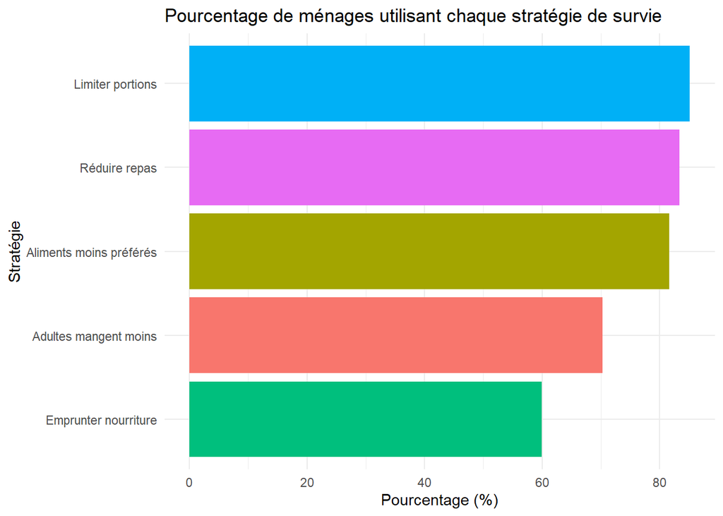

```r
# Visualisation de la proportion de ménages utilisant chaque stratégie
rcsi_data %>%
  pivot_longer(cols = all_of(variables_rcsi),
               names_to = "strategie",
               values_to = "reponse") %>%
  filter(!is.na(reponse)) %>%
  group_by(strategie) %>%
  summarise(pourcentage_oui = mean(reponse == 1, na.rm = TRUE) * 100) %>%
  mutate(strategie = case_when(
    strategie == "Food02a" ~ "Aliments moins préférés",
    strategie == "Food05a" ~ "Emprunter nourriture",
    strategie == "Food06a" ~ "Limiter portions",
    strategie == "Food08a" ~ "Réduire repas",
    strategie == "Food07a" ~ "Adultes mangent moins",
    TRUE ~ strategie
  )) %>%
  ggplot(aes(x = reorder(strategie, pourcentage_oui), y = pourcentage_oui, fill = strategie)) +
  geom_bar(stat = "identity") +
  coord_flip() +
  labs(title = "Pourcentage de ménages utilisant chaque stratégie de survie",
       x = "Stratégie",
       y = "Pourcentage (%)") +
  theme_minimal() +
  theme(legend.position = "none")
```

## 8.2 Création et analyse de nouvelles variables numériques pour le rCSI

```r
# Définir une fonction pour générer aléatoirement des valeurs entre 1 et 7 si oui, sinon 0
set.seed(123) # Pour la reproductibilité

# Création des nouvelles variables
rcsi_data <- rcsi_data %>%
  mutate(
    Food02a_num = ifelse(Food02a == 1, sample(1:7, n(), replace = TRUE), 0),
    Food05a_num = ifelse(Food05a == 1, sample(1:7, n(), replace = TRUE), 0),
    Food06a_num = ifelse(Food06a == 1, sample(1:7, n(), replace = TRUE), 0),
    Food08a_num = ifelse(Food08a == 1, sample(1:7, n(), replace = TRUE), 0),
    Food07a_num = ifelse(Food07a == 1, sample(1:7, n(), replace = TRUE), 0)
  )

# Définir les nouvelles variables numériques
variables_rcsi_num <- c(
  "Food02a_num",
  "Food05a_num",
  "Food06a_num",
  "Food08a_num",
  "Food07a_num"
)

# Statistiques descriptives sur les nouvelles variables
rcsi_num_stats <- rcsi_data %>%
  summarise(across(all_of(variables_rcsi_num),
                   list(
                     moyenne = ~mean(., na.rm = TRUE),
                     mediane = ~median(., na.rm = TRUE),
                     ecart_type = ~sd(., na.rm = TRUE),
                     min = ~min(., na.rm = TRUE),
                     max = ~max(., na.rm = TRUE)
                   )))

# Afficher les statistiques
rcsi_num_stats %>%
  pivot_longer(cols = everything(),
               names_to = c("variable", "stat"),
               names_pattern = "(.*)_(.*)") %>%
  pivot_wider(names_from = stat, values_from = value) %>%
  knitr::kable(caption = "Statistiques descriptives des nouvelles variables numériques du rCSI")
```

Statistiques descriptives des nouvelles variables numériques du rCSI

| variable | moyenne | mediane | type | min | max |
| --- | --- | --- | --- | --- | --- |
| Food02a_num | 3.267997 | 3 | NA | 0 | 7 |
| Food02a_num_ecart | NA | NA | 2.388702 | NA | NA |
| Food05a_num | 2.334753 | 2 | NA | 0 | 7 |
| Food05a_num_ecart | NA | NA | 2.446136 | NA | NA |
| Food06a_num | 3.442698 | 3 | NA | 0 | 7 |
| Food06a_num_ecart | NA | NA | 2.348695 | NA | NA |
| Food08a_num | 3.283611 | 3 | NA | 0 | 7 |
| Food08a_num_ecart | NA | NA | 2.360722 | NA | NA |
| Food07a_num | 2.798099 | 2 | NA | 0 | 7 |
| Food07a_num_ecart | NA | NA | 2.479796 | NA | NA |

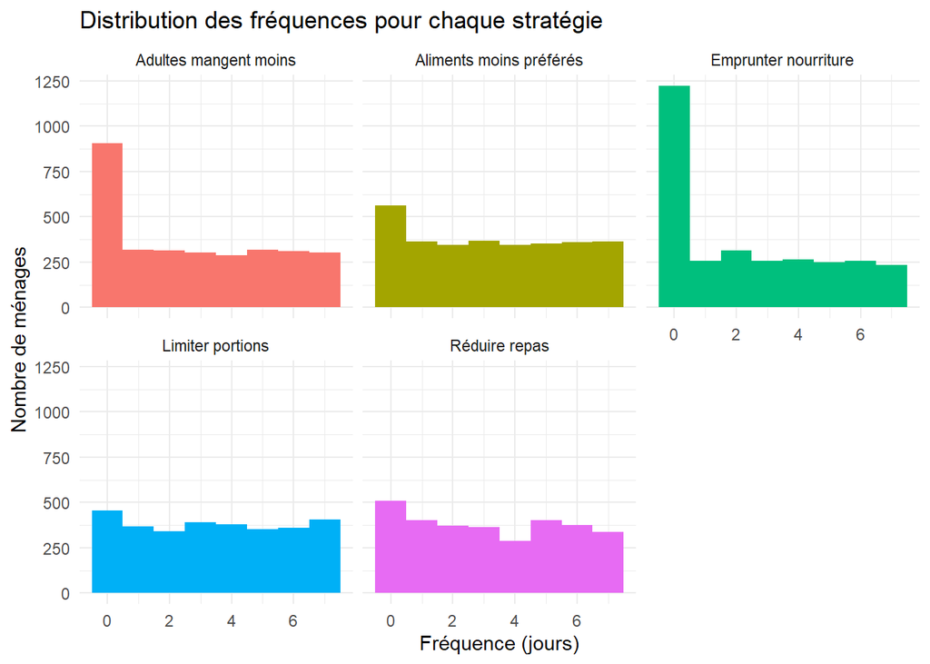

```r
# Visualisation de la distribution des nouvelles variables
rcsi_data %>%
  pivot_longer(cols = all_of(variables_rcsi_num),
               names_to = "strategie",
               values_to = "frequence") %>%
  mutate(strategie = case_when(
    strategie == "Food02a_num" ~ "Aliments moins préférés",
    strategie == "Food05a_num" ~ "Emprunter nourriture",
    strategie == "Food06a_num" ~ "Limiter portions",
    strategie == "Food08a_num" ~ "Réduire repas",
    strategie == "Food07a_num" ~ "Adultes mangent moins",
    TRUE ~ strategie
  )) %>%
  ggplot(aes(x = frequence, fill = strategie)) +
  geom_histogram(binwidth = 1, position = "dodge") +
  facet_wrap(~ strategie) +
  labs(title = "Distribution des fréquences pour chaque stratégie",
       x = "Fréquence (jours)",
       y = "Nombre de ménages") +
  theme_minimal() +
  theme(legend.position = "none")
```

## 8.3 Calcul de l’indice réduit des stratégies de survie (rCSI)

```r
# Tableau des poids attribués à chaque stratégie (somme = 21)
poids_rcsi <- data.frame(
  strategie = c("Aliments moins préférés", "Emprunter nourriture",
                "Limiter portions", "Réduire repas",
                "Adultes mangent moins"),
  variable = c("Food02a_num", "Food05a_num",
               "Food06a_num", "Food08a_num",
               "Food07a_num"),
  poids = c(2, 2, 3, 7, 7)
)

# Vérifier que la somme des poids est égale à 21
sum(poids_rcsi$poids)
```

```
## [1] 21
```

```r
# Afficher le tableau des poids
knitr::kable(poids_rcsi, caption = "Poids attribués aux stratégies pour le calcul du rCSI")
```

Poids attribués aux stratégies pour le calcul du rCSI

| strategie | variable | poids |
| --- | --- | --- |
| Aliments moins préférés | Food02a_num | 2 |
| Emprunter nourriture | Food05a_num | 2 |
| Limiter portions | Food06a_num | 3 |
| Réduire repas | Food08a_num | 7 |
| Adultes mangent moins | Food07a_num | 7 |

```r
# Calculer le rCSI pour chaque ménage
rcsi_data <- rcsi_data %>%
  mutate(
    rcsi_aliments = Food02a_num * 2,
    rcsi_emprunt = Food05a_num * 2,
    rcsi_portions = Food06a_num * 3,
    rcsi_repas = Food08a_num * 7,
    rcsi_adultes = Food07a_num * 7,
    rcsi_total = rcsi_aliments + rcsi_emprunt + rcsi_portions + rcsi_repas + rcsi_adultes
  )

# Statistiques descriptives du rCSI
summary(rcsi_data$rcsi_total)
```

```
##    Min. 1st Qu.  Median    Mean 3rd Qu.    Max.    NA's
##    0.00   43.00   67.00   64.15   87.00  136.00      15
```

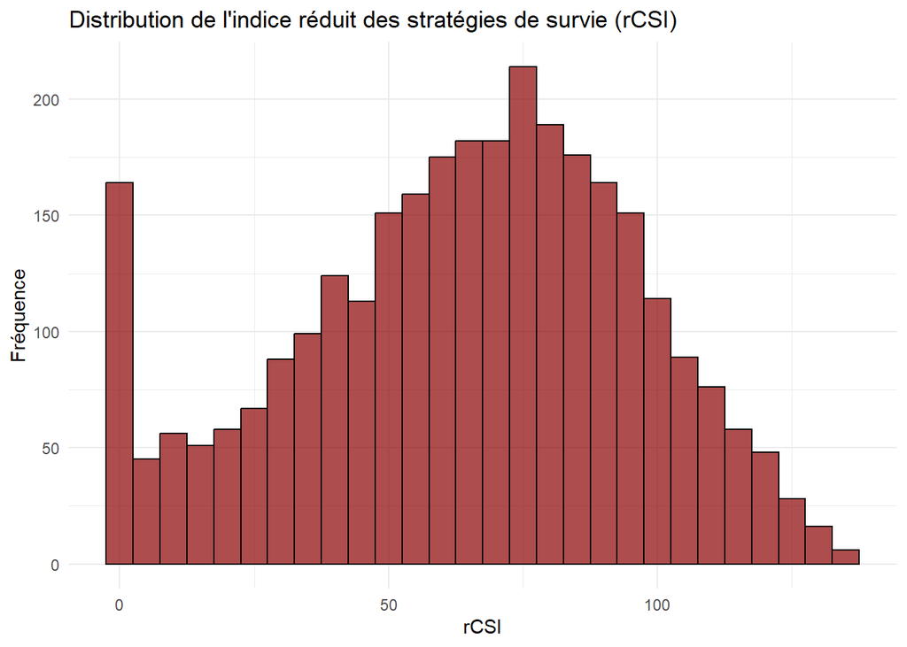

```r
# Histogramme du rCSI
ggplot(rcsi_data, aes(x = rcsi_total)) +
  geom_histogram(binwidth = 5, fill = "darkred", color = "black", alpha = 0.7) +
  labs(title = "Distribution de l'indice réduit des stratégies de survie (rCSI)",
       x = "rCSI",
       y = "Fréquence") +
  theme_minimal()
```

```r
# Catégorisation du niveau de stress alimentaire basé sur le rCSI
rcsi_data <- rcsi_data %>%
  mutate(
    categorie_rcsi = case_when(
      rcsi_total < 5 ~ "Faible",
      rcsi_total >= 5 & rcsi_total < 10 ~ "Moyen-faible",
      rcsi_total >= 10 & rcsi_total < 20 ~ "Moyen-élevé",
      rcsi_total >= 20 ~ "Élevé",
      TRUE ~ NA_character_
    )
  )

# Répartition des ménages par catégorie de rCSI
prop_rcsi <- rcsi_data %>%
  group_by(categorie_rcsi) %>%
  summarise(n = n()) %>%
  mutate(proportion = n / sum(n) * 100)

# Afficher les résultats
knitr::kable(prop_rcsi, caption = "Répartition des ménages par niveau de stress alimentaire")
```

Répartition des ménages par niveau de stress alimentaire

| categorie_rcsi | n | proportion |
| --- | --- | --- |
| Faible | 183 | 5.9843035 |
| Moyen-faible | 47 | 1.5369523 |
| Moyen-élevé | 109 | 3.5644212 |
| Élevé | 2704 | 88.4238064 |
| NA | 15 | 0.4905167 |

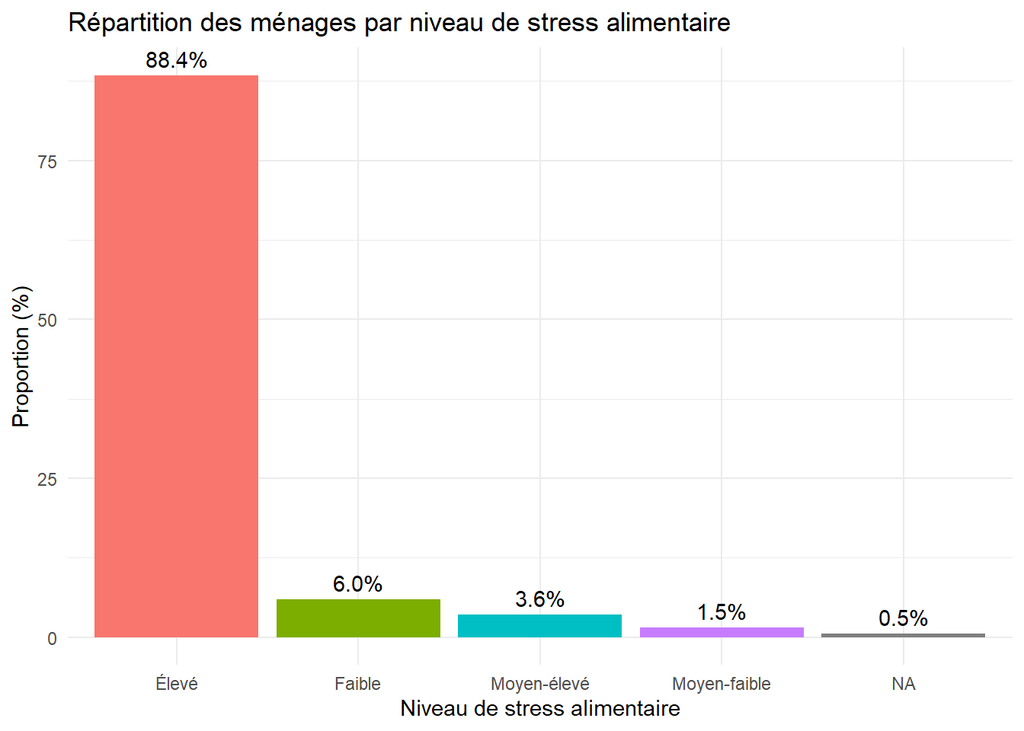

```r
# Visualisation des catégories de rCSI
ggplot(prop_rcsi, aes(x = categorie_rcsi, y = proportion, fill = categorie_rcsi)) +
  geom_bar(stat = "identity") +
  geom_text(aes(label = sprintf("%.1f%%", proportion)), vjust = -0.5) +
  labs(title = "Répartition des ménages par niveau de stress alimentaire",
       x = "Niveau de stress alimentaire",
       y = "Proportion (%)") +
  theme_minimal() +
  theme(legend.position = "none")
```

## 8.4 Représentation spatiale du rCSI selon le milieu de résidence

```r
# Vérifier les labels pour Intro_09 (type de milieu de résidence)
if (any(class(rcsi_data$Intro_09) %in% c("haven_labelled", "labelled"))) {
  cat("Labels pour Intro_09 (milieu de résidence):\n")
  print(val_labels(rcsi_data$Intro_09))
}
```

```
## Labels pour Intro_09 (milieu de résidence):
##      rural peri-urban      urban
##          1          2          3
```

```r
# Statistiques par milieu de résidence
stats_par_milieu <- rcsi_data %>%
  group_by(Intro_09) %>%
  summarise(
    rcsi_moyen = mean(rcsi_total, na.rm = TRUE),
    rcsi_median = median(rcsi_total, na.rm = TRUE),
    rcsi_ecart_type = sd(rcsi_total, na.rm = TRUE),
    n = n(),
    .groups = "drop"
  )

# Afficher les résultats par milieu de résidence
knitr::kable(stats_par_milieu,
             caption = "rCSI moyen par milieu de résidence",
             digits = 1)
```

rCSI moyen par milieu de résidence

| Intro_09 | rcsi_moyen | rcsi_median | rcsi_ecart_type | n |
| --- | --- | --- | --- | --- |
| 1 | 64.8 | 68.0 | 31.4 | 2058 |
| 2 | 60.4 | 63.0 | 32.0 | 740 |
| 3 | 69.6 | 77.0 | 32.1 | 258 |
| NA | 46.5 | 46.5 | 34.6 | 2 |

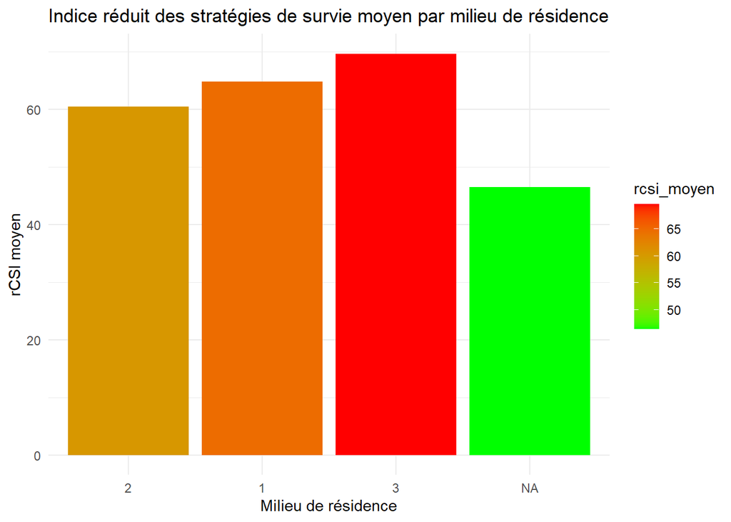

```r
# Visualisation du rCSI moyen par milieu de résidence
ggplot(stats_par_milieu, aes(x = reorder(as.factor(Intro_09), rcsi_moyen), y = rcsi_moyen, fill = rcsi_moyen)) +
  geom_bar(stat = "identity") +
  scale_fill_gradient(low = "green", high = "red") +  # Inverser les couleurs car un rCSI élevé est mauvais
  labs(title = "Indice réduit des stratégies de survie moyen par milieu de résidence",
       x = "Milieu de résidence",
       y = "rCSI moyen") +
  theme_minimal()
```

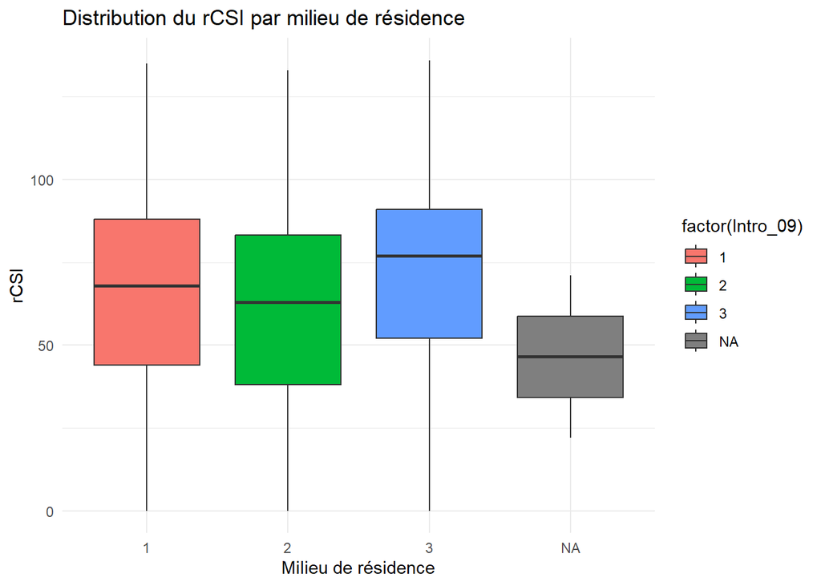

```r
# Boîte à moustaches du rCSI par milieu de résidence
ggplot(rcsi_data, aes(x = factor(Intro_09), y = rcsi_total, fill = factor(Intro_09))) +
  geom_boxplot() +
  labs(title = "Distribution du rCSI par milieu de résidence",
       x = "Milieu de résidence",
       y = "rCSI") +
  theme_minimal()
```

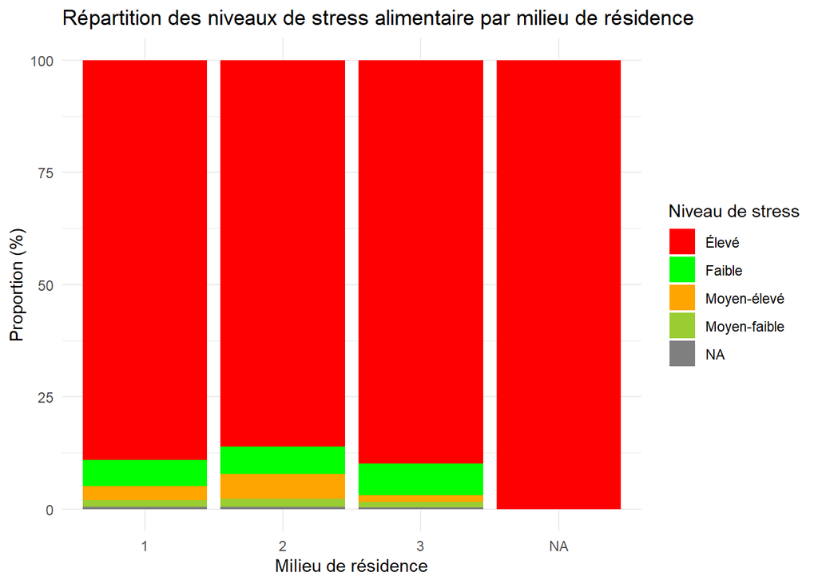

```r
# Proportion des catégories de rCSI par milieu de résidence
prop_rcsi_milieu <- rcsi_data %>%
  group_by(Intro_09, categorie_rcsi) %>%
  summarise(n = n(), .groups = "drop") %>%
  group_by(Intro_09) %>%
  mutate(proportion = n / sum(n) * 100)

# Visualisation des catégories de rCSI par milieu de résidence
ggplot(prop_rcsi_milieu, aes(x = factor(Intro_09), y = proportion, fill = categorie_rcsi)) +
  geom_bar(stat = "identity", position = "stack") +
  scale_fill_manual(values = c("Faible" = "green", "Moyen-faible" = "yellowgreen",
                              "Moyen-élevé" = "orange", "Élevé" = "red")) +
  labs(title = "Répartition des niveaux de stress alimentaire par milieu de résidence",
       x = "Milieu de résidence",
       y = "Proportion (%)",
       fill = "Niveau de stress") +
  theme_minimal()
```

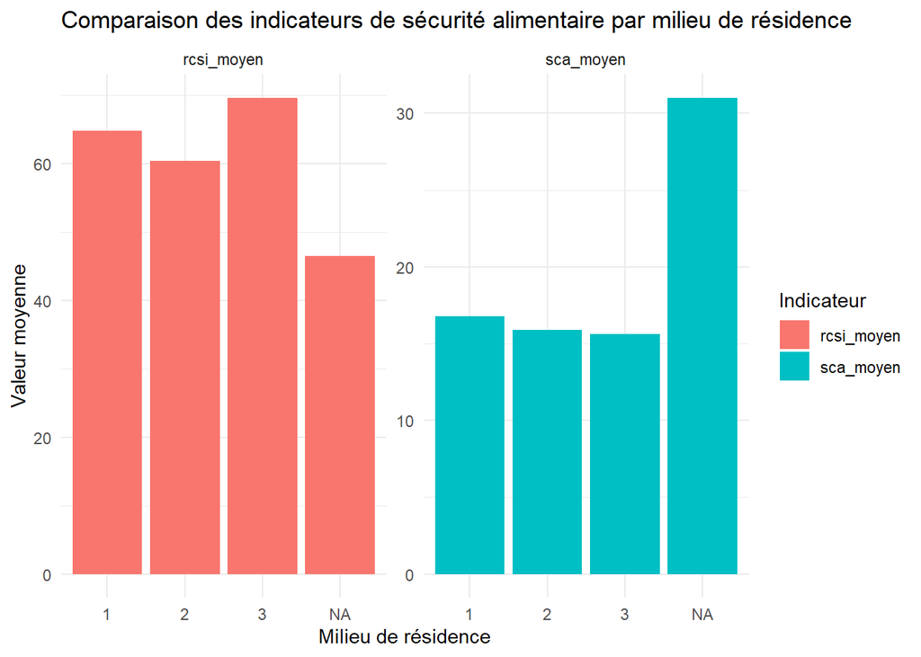

```r
# Analyser simultanément le rCSI et le SCA par milieu de résidence (si disponible)
if (exists("sca_data")) {
  # Joindre les données rCSI et SCA
  securite_alimentaire <- rcsi_data %>%
    select(ID, Intro_09, rcsi_total, categorie_rcsi) %>%
    left_join(sca_data %>% select(ID, sca_total), categorie_sca_21_35, by = "ID")

  # Calculer les moyennes par milieu de résidence
  stats_securite_milieu <- securite_alimentaire %>%
    group_by(Intro_09) %>%
    summarise(
      rcsi_moyen = mean(rcsi_total, na.rm = TRUE),
      sca_moyen = mean(sca_total, na.rm = TRUE),
      n = n(),
      .groups = "drop"
    )

  # Visualisation comparative
  stats_securite_milieu_long <- stats_securite_milieu %>%
    pivot_longer(cols = c(rcsi_moyen, sca_moyen),
                 names_to = "indicateur",
                 values_to = "valeur")

  ggplot(stats_securite_milieu_long, aes(x = factor(Intro_09), y = valeur, fill = indicateur)) +
    geom_bar(stat = "identity", position = "dodge") +
    facet_wrap(~ indicateur, scales = "free_y") +
    labs(title = "Comparaison des indicateurs de sécurité alimentaire par milieu de résidence",
         x = "Milieu de résidence",
         y = "Valeur moyenne",
         fill = "Indicateur") +
    theme_minimal()
}
```

## 8.5 Analyse croisée du rCSI avec d’autres variables socio-démographiques

```r
# Analyser le rCSI selon le groupe de population (réfugiés vs. communautés d'accueil)
stats_rcsi_par_groupe <- rcsi_data %>%
  group_by(Intro_07_1) %>%
  summarise(
    rcsi_moyen = mean(rcsi_total, na.rm = TRUE),
    rcsi_median = median(rcsi_total, na.rm = TRUE),
    n = n(),
    pct_eleve = mean(categorie_rcsi == "Élevé", na.rm = TRUE) * 100,
    .groups = "drop"
  )

# Afficher les résultats par groupe de population
knitr::kable(stats_rcsi_par_groupe,
             caption = "rCSI moyen par groupe de population",
             digits = 1)
```

rCSI moyen par groupe de population

| Intro_07_1 | rcsi_moyen | rcsi_median | n | pct_eleve |
| --- | --- | --- | --- | --- |
| 1 | 66.3 | 70 | 2068 | 89.8 |
| 3 | 59.6 | 62 | 990 | 87.0 |

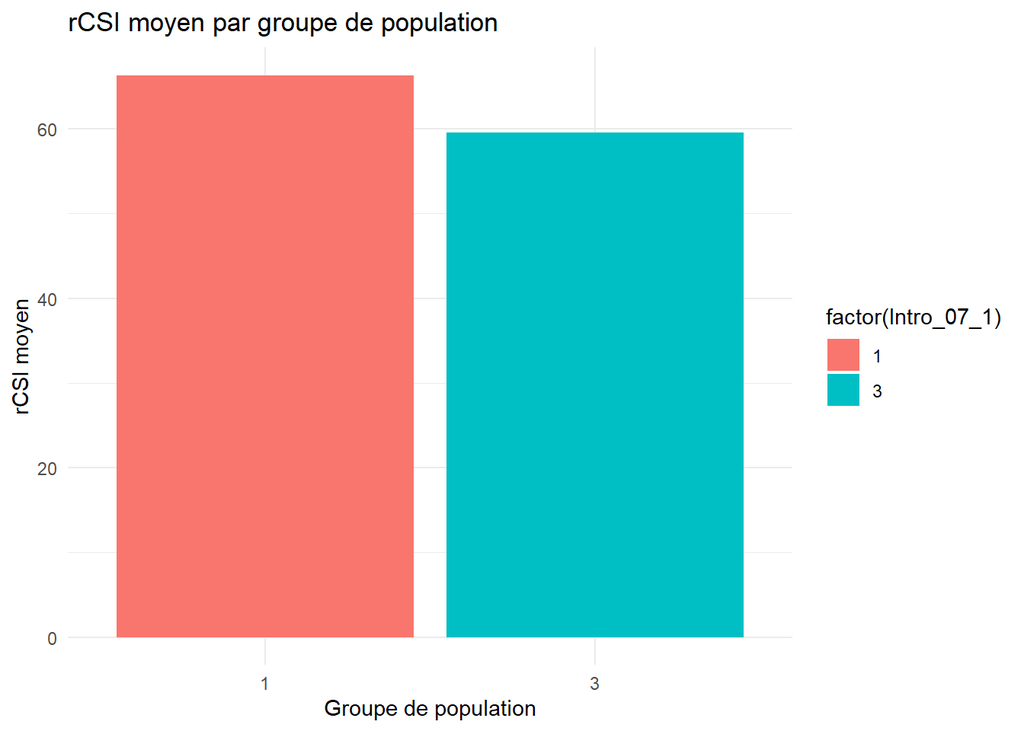

```r
# Visualisation du rCSI moyen par groupe de population
ggplot(stats_rcsi_par_groupe, aes(x = factor(Intro_07_1), y = rcsi_moyen, fill = factor(Intro_07_1))) +
  geom_bar(stat = "identity") +
  labs(title = "rCSI moyen par groupe de population",
       x = "Groupe de population",
       y = "rCSI moyen") +
  theme_minimal()
```

```r
# Test ANOVA pour comparer les moyennes du rCSI entre les groupes de population
if (length(unique(na.omit(rcsi_data$Intro_07_1))) > 1) {
  cat("Test ANOVA pour comparer les moyennes du rCSI entre les groupes:\n")
  print(summary(aov(rcsi_total ~ factor(Intro_07_1), data = rcsi_data)))
}
```

```
## Test ANOVA pour comparer les moyennes du rCSI entre les groupes:
##                      Df  Sum Sq Mean Sq F value   Pr(>F)
## factor(Intro_07_1)    1   30332   30332   30.53 3.57e-08 ***
## Residuals          3041 3021305     994
## ---
## Signif. codes:  0 '***' 0.001 '**' 0.01 '*' 0.05 '.' 0.1 ' ' 1
## 15 observations effacées parce que manquantes
```

Les résultats de l’ANOVA indiquent une différence statistiquement significative entre les moyennes du rCSI des réfugiés et des communautés d’accueil (F(1, 3041) = 30.53, p < 0.0001), avec une valeur-p extrêmement faible (3.57e-08) qui permet de rejeter fortement l’hypothèse nulle. Bien que la variance expliquée par l’appartenance au groupe soit relativement faible (environ 1% de la variabilité totale), la taille importante de l’échantillon (n = 3043 après exclusion de 15 observations manquantes) confère une puissance statistique élevée à cette analyse. Ces résultats suggèrent que les réfugiés présentent des niveaux d’insécurité alimentaire significativement plus sévères que les communautés d’accueil, tel que mesuré par le rCSI. Cependant, l’ampleur limitée de la variance expliquée souligne la nécessité d’étudier d’autres facteurs susceptibles d’influencer les stratégies d’adaptation alimentaire, comme l’accès aux ressources économiques ou aux aides humanitaires.